# 통계밥법론2 Chap7 실습코드

202140191 엄태훈

2021-10-30(SAT)

# Chap7 Logistic Regression Models

반응변수가 범주형(보통 이항이지만, 셋 이상)인 경우에는 연속형 변수와 다른 모델링 프레임워크 및 시각화 방법을 사용해야 한다.  
기존에 사용하던 선형회귀모델을 적합시키게 되면, 반응변수가 범주형이기 때문에 모델이 적절한 예측을 제공하지 못할수도 있다.  
또한, 설명변수에 모델을 적합시킨 후에는 유의한 설명변수가 무엇인지를 확인하고 잔차진단 과정을 통해 결과를 왜곡할 수 있는 이상치를 탐지하고 결과를 통해 통계적 추론 및 예측을 진행한다.

## 7.1 Introduction

지금까지 우리가 살펴본 Chapter를 통해 범주형 변수 간의 관계를 확인하고 이러한 결과를 시각화 할 수 있는 방법들에 대해서 알아보았다.  
Chpater7에서는 **반응변수가 범주형 변수**인 경우의 데이터 분석을 위핸 모델링 기반 방법에 대해서 알아본다.  
여기서 사용되는 모델들은 관측치에 대해 확률 분포를 고려하고 모델에 의해 설명되는 체계적 성분과 그렇지 않은 무작위 성분을 명확히 구별한다는 점에서 우리가 이전에 살펴봤던 모델들과는 차이가 있다.  
모델 기반 접근방식을 통해 불확실성에 대한 측정과 동시에 설명 변수 범위에 대해 예측 값을 추정할 수 있는 능력을 통해 범주형 데이터를 간결하게 요약할 수 있다.

## 7.2 The logistic regression model

**로지스틱 회귀 모형(Logistic regression model)**은 반응변수가 이산형 변수일 때, 반응변수와 설명 변수 집합 사이의 관계를 설명하는데 사용된다.  
선형 회귀분석이 독립변수와 종속변수 사이의 선형적 관계를 살펴보는 것이라면, 로지스틱 회귀분석은 일반화 선형모형의 특수한 경우로 그래프가 S형 곡선을 가지고 있는 것이 특징이다.

또한, 로짓(logit)함수를 사용하여 출력값의 범위를 [0,1]로 제한하는데, 이는 로지스틱 회귀모형의 핵심 아이디어 중 하나로 확률적으로 결과를 해석할 수 있도록 돕는다.

$$logit(\pi) = log (\frac{\pi}{ 1- \pi}) \\ (여기서, \pi = 확률)$$

일반적으로 출력값이 0.5보다 클 경우, 사건이 발생한다고 예측하고 출력값이 0.5보다 작을 경우에는 사건이 발생하지 않는다고 가정한다.  
EX)

- 고객 신용도 평가 (우량 / 불량),
- 심장병 예측 (발생 / 발생 X) 등

이때, **threshold**로 사용되는 0.5의 경우 연구자의 연구목적에 따라 다른 값을 지정할 수도 있다.

```r
library(MASS)
p <- c(0.05, 0.10, 0.25, 0.50, 0.75, 0.90, 0.95)
odds <- p / (1 - p)
data.frame(p,
           odds = as.character(fractions(odds)),
           logit = log(odds))
```

```
##      p odds     logit
## 1 0.05 1/19 -2.944439
## 2 0.10  1/9 -2.197225
## 3 0.25  1/3 -1.098612
## 4 0.50    1  0.000000
## 5 0.75    3  1.098612
## 6 0.90    9  2.197225
## 7 0.95   19  2.944439
```

`logit`함수는 앞서 설명한 것처럼 오즈에 **log**를 취한 형태로 쓰이는 것을 확인할 수 있다.

```r
library(popbio)
library(vcd)
```

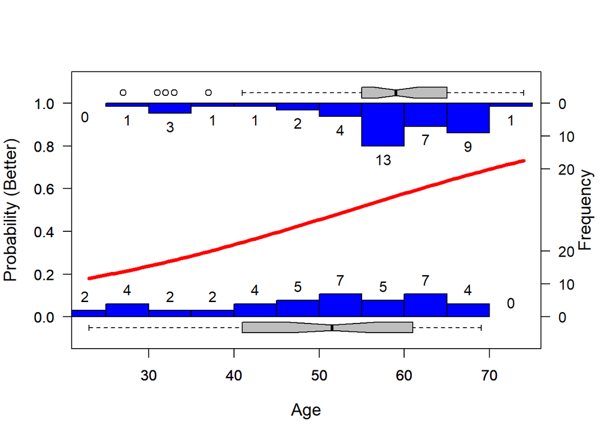

```r
logi.hist.plot(Arthritis$Age, Arthritis$Improved > "None", type = "hist",
                       counts = TRUE, ylabel = "Probability (Better)",xlab = "Age")
```

`pobio`패키지는 연령 또는 단계별로 표시된 데이터에 대한 투영 행렬 모델을 구성하고 분석하도록 도와주는 패키지이다.

`logi.hist.plot`함수는 히스토그램과 상자그림을 이용하여 더 나은 반응에 대한 관측치의 확률의 조건부 분포를 확인할 수 있다.  
- `logi.hist.plot(x,y,type,counts)`

- x: x축에 사용될 데이터
- y: y축에 사용될 데이터
- type: 시각화 타입
- counts: 빈도표시 여부

`logi.hist.plot`을 `Arthritis`데이터의 **Age, Improved**변수를 통해 그려보았다. 0과 1로 분류될 경우에 각 연령에 대한 빈도 및 히스토그램, 상자그림을 통해 반응변수에 대한 전반적인 설명변수의 분포를 확인할 수 있다.  
또한, **나이가 증가할수록 약의효과가 좋게 나타날 확률이 점점 높아지는 것**을 볼 수 있다.

### 7.2.1 Fitting a logistic regression model

R에서는 `glm`함수를 사용하여 로지스틱 회귀모형을 적합시킬 수 있다.  
이때, `family = binomial(link = logit)`옵션을 적용하는데, 로지스틱 회귀모형의 경우 반응변수가 이항변수가 되도록 설정해야하며 **logit link function**을 사용해야 하기때문에 `family = binomial`옵션을 지정한다.  
`family = binomial`옵션을 지정하게 되면 `link`옵션을 입력하지 않아도 `link function`은 자동으로 **logit**으로 설정이 된다.

*Example 7.1: Arthritis treatment*

```r
library(vcd)
data("Arthritis", package  = "vcd")
Arthritis$Better <- as.numeric(Arthritis$Improved > "None")
```

**Improved = None**이 아닐 경우 1을 가지고 **Improved = None**인 경우에는 0을 가지는 변수 `Better`을 새로 생성하였다.

```r
arth.logistic <- glm(Better ~ Age, data = Arthritis, family = binomial)
arth.logistic
```

```
##
## Call:  glm(formula = Better ~ Age, family = binomial, data = Arthritis)
##
## Coefficients:
## (Intercept)          Age
##    -2.64207      0.04925
##
## Degrees of Freedom: 83 Total (i.e. Null);  82 Residual
## Null Deviance:       116.4
## Residual Deviance: 109.2     AIC: 113.2
```

**Better**를 반응변수로 하고 **Age**를 설명변수로 하는 로지스틱 회귀모형 `arth.logistic`을 생성하였다.  
로지스틱 회귀모형을 적합시키게 되면, 추정된 설명변수의 계수와 모형의 잔차, AIC 등의 정보를 얻을 수 있다.

```r
library(lmtest)
coeftest(arth.logistic)
```

```
##
## z test of coefficients:
##
##              Estimate Std. Error z value Pr(>|z|)
## (Intercept) -2.642071   1.073167 -2.4619  0.01382 *
## Age          0.049249   0.019357  2.5443  0.01095 *
## ---
## Signif. codes:  0 '***' 0.001 '**' 0.01 '*' 0.05 '.' 0.1 ' ' 1
```

`lmtest`패키지는 선형 회귀 분석 모형에서 진단 검사를 위한 검정, 데이터 집합 예제를 제공하며 **parametric**모델의 추론을 도와주는 함수를 제공한다.

`coeftest`는 추정된 계수에 대해 **Wald**검정을 수행하고 검정에 대한 신뢰구간을 계산하기위한 함수이며, `lmtest`패키지에 포함돼있다.  
- `coeftest(model)`

- model: wald 검정을 수행할 적합된 모델

`coeftest`를 `arth.logistic`모델에 사용한 결과, **절편, Age**는 유의확률이 유의수준 0.05보다 작으므로 귀무가설을 기각한다.

- H0: 주어진 설명변수의 계수는 0이다. 즉, 주어진 설명변수는 유의하지 않다.
- H1: 주어진 설명변수의 계수는 0이 아니다. 즉, 주어진 설명변수는 유의하다.

따라서, **Age**는 유의한 변수임을 확인할 수 있다.

`arth.logistic`모형을 통해 추정된 식은 다음과 같다.

$$logit(\pi) = -2.642071 + 0.049249 * Age$$

```r
exp(coef(arth.logistic))
```

```
## (Intercept)         Age
##   0.0712136   1.0504819
```

추정된 로지스틱 회귀모형의 계수에 `exp`를 취하게 되면 각 설명변수에 대한 오즈비를 구할 수 있다.  
나이가 1단위 증가할수록 약의 효과가 뚜렷할 오즈가 **exp(0.049249) = 1.05**배 증가한다.

```r
exp(10 * coef(arth.logistic)["Age"])
```

```
##      Age
## 1.636386
```

계수에 10을 곱하게 되면 단위가 10으로 바뀌게 되므로, 나이가 10단위 증가할수록 약의 효과가 뚜렷할 오즈가 **1.63**배 증가하는 것을 확인할 수 있다.

```r
arth.lm <- glm(Better ~ Age, data = Arthritis)
coef(arth.lm)
```

```
## (Intercept)         Age
## -0.10716962  0.01137935
```

`glm`함수의 옵션에서 `family = binomial`옵션을 지정하지 않을 경우, 로지스틱 회귀모형이 아닌 일반 선형회귀 모델에 적합시키게 된다.  
일반 선형회귀 모형에 데이터를 적합시키게 되면 추정된 계수가 달라질 뿐만아니라 로지스틱 회귀모형과 다른 결과가 도출될수도 있다.

```r
summary(arth.lm)
```

```
##
## Call:
## glm(formula = Better ~ Age, data = Arthritis)
##
## Deviance Residuals:
##      Min        1Q    Median        3Q       Max
## -0.67801  -0.47602   0.05527   0.43579   0.79993
##
## Coefficients:
##              Estimate Std. Error t value Pr(>|t|)
## (Intercept) -0.107170   0.228415  -0.469   0.6402
## Age          0.011379   0.004165   2.732   0.0077 **
## ---
## Signif. codes:  0 '***' 0.001 '**' 0.01 '*' 0.05 '.' 0.1 ' ' 1
##
## (Dispersion parameter for gaussian family taken to be 0.2347266)
##
##     Null deviance: 21.000  on 83  degrees of freedom
## Residual deviance: 19.248  on 82  degrees of freedom
## AIC: 120.61
##
## Number of Fisher Scoring iterations: 2
```

일반 선형회귀 모델에 데이터를 적합시킨 결과, 절편은 유의하지 않지만 **Age**는 유의확률이 유의수준 0.05보다 작으므로 유의한 변수임을 알 수 있다.  
`Arthritis` 데이터의 경우, 로지스틱 회귀 모델, 일반 선형회귀 모델 모두 설명변수 **Age**가 유의하게 나오는 것을 확인할 수 있다.

### 7.2.2 Model tests for simple logistic regression

로지스틱 회귀 모형에 대해 수행할 수 있는 두 가지 주요 가설 검정 유형이 있다. 이 주제에 대해서는 7.3에서 더 자세히 다루며, 여기서는 `Arthritis`데이터를 이용하여 주요 아이디어를 살펴본다.  
가장 기본적인 가설 검정은 $logit(\pi) = \alpha$일때보다 얼마나 나은가 즉, $H_0: \beta = 0$에 대한 검정을 진행한다.

두 번째 가설 검정은 데이터를 통해 얻은 모델이 포화모델과 비교했을 때, 얼마나 나쁜 모델인가에 대한 검정을 진행하는 것이다.  
여러 데이터를 추가하여 모델은 더 복잡해졌지만, 모델의 잔차가 기존의 간단한 모델과 비교했을 때 비슷한 수준이라면, 복잡한 모델을 사용할 필요가 없다.

```r
anova(arth.logistic, test = "Chisq")
```

```
## Analysis of Deviance Table
##
## Model: binomial, link: logit
##
## Response: Better
##
## Terms added sequentially (first to last)
##
##
##      Df Deviance Resid. Df Resid. Dev Pr(>Chi)
## NULL                    83     116.45
## Age   1   7.2852        82     109.16 0.006953 **
## ---
## Signif. codes:  0 '***' 0.001 '**' 0.01 '*' 0.05 '.' 0.1 ' ' 1
```

`anova`를 통해 기존에 절편만으로 설명된 모델에 **Age**변수를 추가할 경우, **Age**변수는 유의한 영향을 미치는지에 대한 검정을 진행해 보았다.  
**Age**의 유의확률이 유의수준 0.05보다 작으므로 귀무가설을 기각한다. 따라서, **Age**변수의 계수는 0이 아니며, 모형에 유의한 영향을 주는 변수임을 알 수 있다.

```r
library(vcdExtra)
LRstats(arth.logistic)
```

```
## Likelihood summary table:
##                  AIC    BIC LR Chisq Df Pr(>Chisq)
## arth.logistic 113.16 118.03   109.16 82    0.02416 *
## ---
## Signif. codes:  0 '***' 0.001 '**' 0.01 '*' 0.05 '.' 0.1 ' ' 1
```

`LRstats`를 통해 모형의 검정을 진행한 결과, 유의확률이 유의수준 0.05보다 작으므로 **포화모델의 잔차**와 **적합시킨 모델의 잔차**는 서로 유의한 차이가 있는 것을 알 수 있다.  
따라서, 기존모델에 **Age**변수를 추가하여 모델을 적합시키는 것은 유의하다고 볼 수 있다.

### 7.2.3 Plotting a binary response

이항 반응 변수에 대한 모델을 적응 시킨 후 결과만을 통해 변수들의 관계를 해석하는 것과 이해하는 것은 쉽지않다.  
이러한 경우, 적합시킨 모형과 함께 시각화 방법을 이용하면 모형을 이해하는 데 큰 도움이 된다.

*Example 7.2: Arthritis treatment - Plotting logistic regression with base graphics*

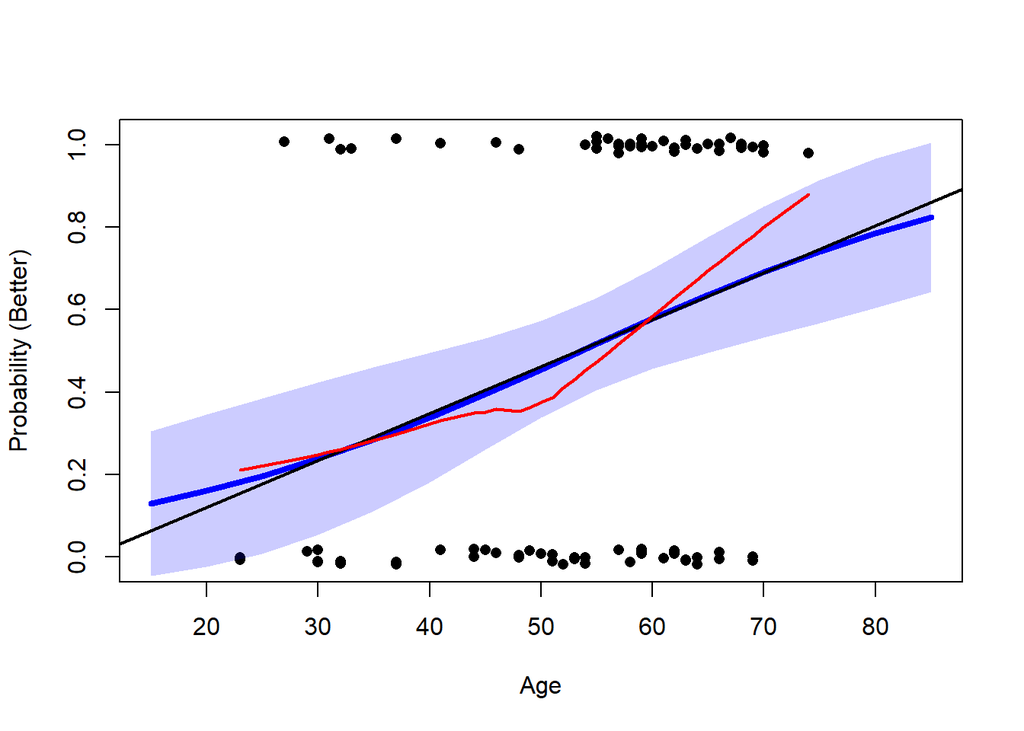

```r
plot(jitter(Better, .1) ~ Age, data = Arthritis,
     xlim = c(15,85), pch = 16,
     ylab = "Probability (Better)")
xvalues <- seq(15, 85, 5)
pred.logistic <- predict(arth.logistic,
                         newdata = data.frame(Age = xvalues),
                         type = "response", se.fit = TRUE)

upper <- pred.logistic$fit + 1.96 * pred.logistic$se.fit
lower <- pred.logistic$fit - 1.96 * pred.logistic$se.fit

polygon(c(xvalues, rev(xvalues)),
        c(upper, rev(lower)),
        col = rgb(0, 0, 1, .2), border = NA)
lines(xvalues, pred.logistic$fit, lwd = 4, col = "blue")
abline(arth.lm, lwd = 2)
lines(lowess(Arthritis$Age, Arthritis$Better, f = .9),
      col = "red", lwd = 2)
```

적합된 로지스틱 모형의 경우, 로지스틱 회귀 분석을 저장한 객체를 통해 얻을 수 있으며, 이 모형을 통해 적합된 곡선과 새로운 데이터에 대한 예측을 진행할 수 있다.

새로운 데이터를 얻었을 때, 적합된 모델을 새로운 데이터에 대한 예측에 사용하기 위해서는 `predict`함수를 사용한다.  
- `predict(model,newdata,type,se.fit)`

- model: 적합시킬 모델
- newdata: 새로운 데이터
- type: 예측의 형태 (“response”로 지정하게 되면 반응변수가 0 ~ 1 사이의 값을 가짐)
- se.fit: 표준오차 포함 여부

**검은색 점**의 경우, 새로운 데이터를 로지스틱 회귀모형에 적합시켰을때의 출력값을 나타내며, 가운데의 **보라색 band**는 로지스틱 회귀 곡선에 대한 신뢰수준 95%의 band를 나타낸다.  
**파란색 선**의 경우 예측값에 대한 로지스틱 회귀 곡선, **빨간색 선**의 경우 우리가 적합한 데이터에 대한 비모수적인 회귀 곡선을 나타낸다.

*Example 7.3: Arthritis treatment - Plotting logistic regression with ggplot2*

```r
library(ggplot2)
# basic logistic regression plot
gg <- ggplot(Arthritis, aes(x = Age, y = Better)) +
  xlim(5, 95) +
  geom_point(position = position_jitter(height = 0.02, width = 0))+
  stat_smooth(method = "glm", family = binomial,
              alpha = 0.1, fill = "blue", size = 2.5,
              fullrange = TRUE)
```

```r
gg <- gg + stat_smooth(method = "lm", se = FALSE,
                       size = 1.2, color = "black",
                       fullrange = TRUE)
gg <- gg + stat_smooth(method = "loess", se = FALSE,
                       span = 0.95, colour = "red", size = 1.2)
```

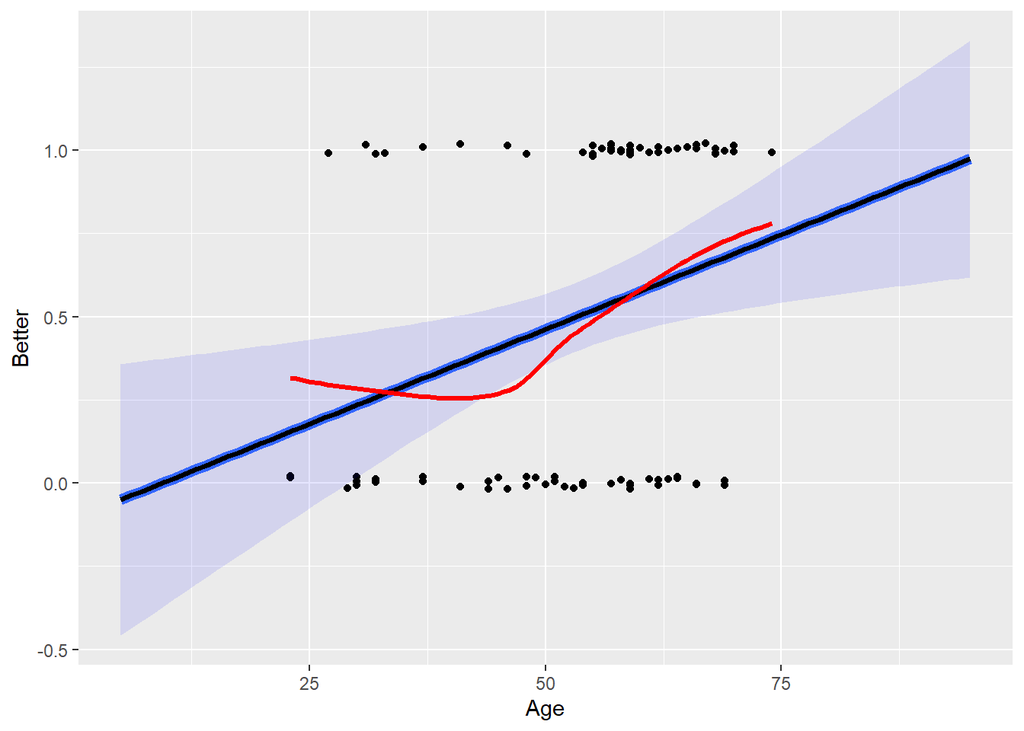

```r
gg
```

기본적인 plot함수를 이용하지 않고 `ggplot`함수를 통해서도 시각화를 진행할 수 있다.  
ggplot을 통해 시각화를 진행한 결과, 앞서 그렸던 그림과 상당히 유사한 그림을 얻는 것을 확인할 수 있다.  
`stat_smooth(method = glm, family = binomial)`을 지정하게 되면 로지스틱 회귀 모형에 대한 적합선을, `stat_smooth(method = lm)`은 선형 회귀모형에 대한 적합선, `stat_smooth(method = loess)`은 비모수적 접근을 통한 회귀 적합선을 나타낸다.

**파란색**선이 로지스틱 회귀모형의 적합선, **검은색**선이 선형 회귀모형의 적합선, **빨간색**선이 비모수적인 접근을 통한 회귀 적합선을 나타낸다.  
**보라색**band는 앞선 plot과 동일하게 로지스틱 회귀 적합선에 대한 신뢰수준 95%의 band를 나타낸다.

### 7.2.4 Grouped binomial data

이항 변수의 데이터가 관측치가 아닌 성공, 실패에 대해 기록된 형태의 데이터로 주어질 수 있다.

이때, 실패횟수, 성공횟수에 대한 2열의 행렬로 구성된 응답으로 데이터를 재구성해야 하며, 적합 모형을 확률로 표시할 때에는 일반적으로 성공에 대한 비율을 사용한다. 또는, trials를 이용하여 모형을 적합시킬수도 있다.

*Example 7.4: Space shuttle disaster*

```r
data("SpaceShuttle" , package = "vcd")
head(SpaceShuttle)
```

```
##   FlightNumber Temperature Pressure Fail nFailures Damage
## 1            1          66       50   no         0      0
## 2            2          70       50  yes         1      4
## 3            3          69       50   no         0      0
## 4            4          80       50 <NA>        NA     NA
## 5            5          68       50   no         0      0
## 6            6          67       50   no         0      0
```

`SpaceShuttle`데이터는 NASA의 우주왕복선 프로그램의 O-ring 실패에 관한 자료이며, `vcd`패키지에 포함돼있다.

- FlightNumber: 비행번호 (Norminal variable)
- Temperature: 시작시 온도 (Discrete variable)
- Pressure: 압력 (Discrete variable)
- Fail: O-ring 실패 발생여부 (Factor variable - No,Yes)
- nFailures: O-ring 실패횟수 (Discrete variable)
- Damage: 피해지수 (Damage index)

```r
shuttle.mod <- glm(cbind(nFailures, 6 - nFailures) ~ Temperature, data = SpaceShuttle, na.action = na.exclude,
                   family = binomial)
```

`shuttle.mod`은 이항 반응변수에 대해서 성공, 실패에 대해 2열의 행렬로 구성한 후, **Temperature**를 설명변수로 하는 로지스틱 회귀모형을 적합시킨 결과이다.  
`na.action = na.exclude`는 결측치를 제거하고 분석을 진행하라는 옵션이다.

```r
SpaceShuttle$trials <- 6
shuttle.modw <- glm(nFailures / trials ~ Temperature,
                    weight= trials, data = SpaceShuttle,
                    na.action = na.exclude, family = binomial)
```

`shuttle.modw`은 이항 반응 변수에 대해서 trials과 실패횟수를 활용한후, **Temperature**를 설명변수로 하는 로지스틱 회귀모형을 적합시킨 결과이다.

```r
all.equal(coef(shuttle.mod), coef(shuttle.modw))
```

```
## [1] TRUE
```

`all.equal`을 통해 두 모형의 계수를 확인해 본 결과, 반응변수에 대해서 각각 다른 방법을 사용하여 설정하고 로지스틱 회귀모형을 적합했어도 서로 같은 계수값을 가지는 것을 확인할 수 있다.

```r
anova(shuttle.mod, test = "Chisq")
```

```
## Analysis of Deviance Table
##
## Model: binomial, link: logit
##
## Response: cbind(nFailures, 6 - nFailures)
##
## Terms added sequentially (first to last)
##
##
##             Df Deviance Resid. Df Resid. Dev Pr(>Chi)
## NULL                           22     24.230
## Temperature  1    6.144        21     18.086  0.01319 *
## ---
## Signif. codes:  0 '***' 0.001 '**' 0.01 '*' 0.05 '.' 0.1 ' ' 1
```

`anova`를 통해 기존에 절편만으로 설명된 모델에 **Temperature**변수를 추가할 경우, **Temperature**변수는 유의한 영향을 미치는지에 대한 검정을 진행해 보았다.  
**Temperature**의 유의확률이 유의수준 0.05보다 작으므로 귀무가설을 기각한다. 따라서, **Temperature**변수의 계수는 0이 아니며, 모형에 유의한 영향을 주는 변수임을 알 수 있다.

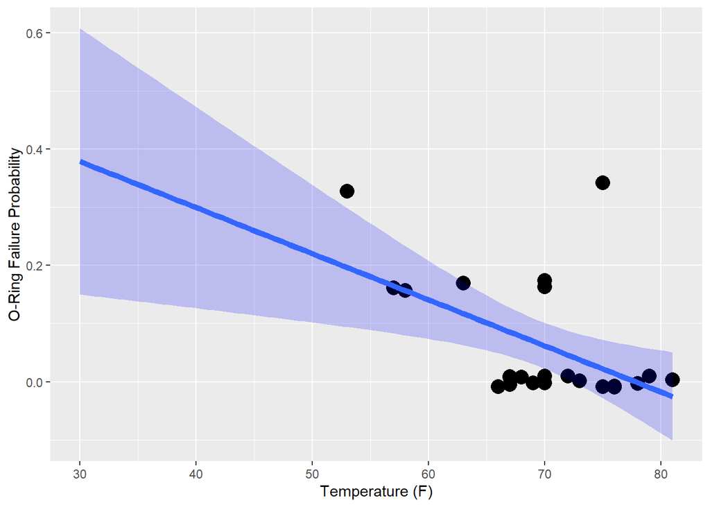

```r
library(ggplot2)
ggplot(SpaceShuttle, aes(x = Temperature, y = nFailures / trials)) +
  xlim(30, 81) +
  xlab("Temperature (F)") +
  ylab("O-Ring Failure Probability") +
  geom_point(position = position_jitter(width = 0, height = 0.01), aes(size = 2)) +
  theme(legend.position = "none") +
  geom_smooth(method = "glm", family = binomial, fill = "blue", aes(weight = trials), fullrange = TRUE, alpha = 0.2,size = 2)
```

`ggplot`을 이용하여 **Temperature**의 관측값에 따른 로지스틱 회귀분석 결과에 대한 시각화를 진행하였다.  
`fullrange = TRUE`로 설정할 경우, 적합 회귀 곡선과 신뢰 밴드를 전체 범위로 확장한다.  
**파란선**의 경우 적합 로지스틱회귀 곡선, **보라색**의 경우 적합식에 대한 신뢰수준 95% band를 나타낸다.

그림을 보면 **Temperature**이 높아질수록 **Probability**가 0에 가까워지는 것을 확인할 수 있다. 즉, **Temperature**이 높을수록 반응변수의 사건이 발생하지 않을 것으로 분류할 확률이 높다라고 할 수 있다.

## 7.3 Multiple logistic regression models

일반선형회귀 모형의 경우, 독립변수가 하나인 단순회귀, 독립변수가 여러개인 다중회귀로 구분할 수 있다.  
로지스틱 회귀모형 또한 **독립변수를 여러개**를 사용하여 **다중 로지스틱 회귀모델**을 생성할 수 있다.

*Example 7.5: Arthritis treatment*

```r
arth.logistic2 <- glm(Better ~ I(Age-50) + Sex + Treatment,
                      data = Arthritis,
                      family = binomial)
```

`Arthritis`데이터의 **Better**를 반응변수로하고 **Age, Sex, Treatment**를 독립변수로 활용하는 **다중 로지스틱 회귀분석**을 진행해 보았다. 여기서, 절편 해석의 용이함을 위해 **Age**가 아닌 **Age-50**을 적합시켜 평균에 조금 더 가까운 모형을 적합시켰다.  
**Age-50**을 적합시키게 되면, **Age**변수의 계수는 그대로이지만, 절편의 계수만 바뀌는 것을 확인할 수 있다.

```r
coeftest(arth.logistic2)
```

```
##
## z test of coefficients:
##
##                   Estimate Std. Error z value Pr(>|z|)
## (Intercept)      -0.578134   0.367378 -1.5737 0.115562
## I(Age - 50)       0.048747   0.020663  2.3591 0.018318 *
## SexMale          -1.487831   0.594769 -2.5015 0.012366 *
## TreatmentTreated  1.759804   0.536495  3.2802 0.001037 **
## ---
## Signif. codes:  0 '***' 0.001 '**' 0.01 '*' 0.05 '.' 0.1 ' ' 1
```

`coeftest`를 통해 계수에 대한 검정을 진행해 보았다.  
절편을 제외한 **Age, Sex, Treatment**변수 모두 유의확률이 유의수준 0.05보다 작으므로 귀무가설을 기각한다. 따라서, 설명변수들의 계수는 0이 아니므로 유의한 변수들임을 확인할 수 있다.

모형을 통해 추정된 로지스틱 회귀식은 아래와 같다.

$$logit(\pi) = -0.578134 + 0.048747 Age -1.487831sex + 1.759804 Treatment$$

위의 식에서 **Sex = Male이면 1, Sex = Female이면 0**의 값을 가지고 **Treatment = Treated이면 1, Treatment = Placebo이면 0**의 값을 가진다.

```r
exp(cbind(OddsRatio = coef(arth.logistic2),
          confint(arth.logistic2)))
```

```
##                  OddsRatio      2.5 %     97.5 %
## (Intercept)      0.5609441 0.26474942  1.1323435
## I(Age - 50)      1.0499542 1.01000124  1.0963021
## SexMale          0.2258620 0.06523759  0.6890789
## TreatmentTreated 5.8112990 2.11870182 17.7265830
```

### 7.3.1 Conditional plots

가장 간단한 그림에서는 하나 이상의 반응 변수에 대해, 정의된 데이터의 부분 집합에 대해 개별적으로 적합 관계(예측값, 신뢰구간 band)를 표시한다.  
또한, 여러 패널을 통해 데이터에 대해서 수준 별로 시각화를 진행할수도 있다.

*Example 7.6: Arthritis treatment - conditional plots*

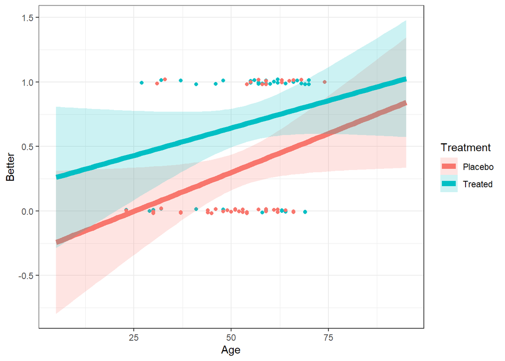

```r
library(ggplot2)
gg <- ggplot(Arthritis, aes(Age, Better, color = Treatment)) +
  xlim(5,95)+
  theme_bw()+
  geom_point(position = position_jitter(height = 0.02, width =0))+
  stat_smooth(method = "glm", family = binomial,
              alpha = 0.2, aes(fill = Treatment),
              size = 2.5, fullrange = TRUE)
gg
```

위 그림의 경우, 데이터가 **Treatment = Treated일 때 파란색**, **Treatment = Placebo일 때, 빨간색**으로 구분하여 각 데이터의 위치, 적합 회귀선, 신뢰구간 band를 나타내었다.  
**Treatment = Treated**인 경우, 0보다는 1(약의 효능이 있다.)로 더 많이 분류하는 것을 볼 수 있었고 나이가 증가함에 따라 적합 회귀선 또한 **Treatment = Placebo**에 비해 1로 더 빠르게 수렴하는 것을 볼 수 있다.

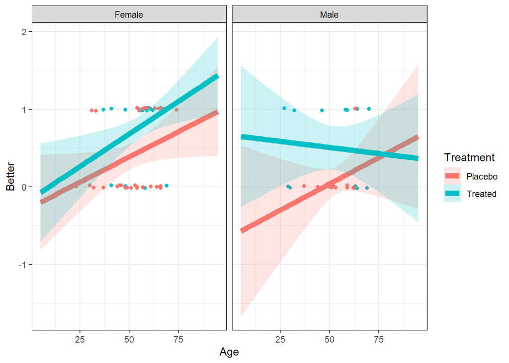

```r
gg + facet_wrap(~ Sex)
```

`facet_wrap`함수는 1d 시퀀스의 패널을 2d로 전환해주는 함수로 `ggplot2`패키지에 포함돼있다.  
- `facet_wrap(variable)`

- variable: 패널을 나누고자 하는 기준 변수

기존에 그린 그림에서 `facet_wrap`함수를 사용하여 **Sex의 수준(Female, Male)**에 따라 패널을 분리하였다.

**Sex = Female**의 경우 앞서 살펴본 그림과 동일하게 **Treatment = Treated**일 때, 나이가 증가함에 따라 1의 확률로 더 빠르게 수렴한다.  
하지만, **Sex = Male**의 경우 **Sex = Female**과 다르게 **Treatment = Treated**일 경우 나이가 증가함에 따라 **Better**에 대한 확률이 감소하며, **Treatment = Placebo**일 경우 나이가 증가함에 따라 **Better**에 대한 확률이 증가하는 **Age**와 **Treatment**의 단계 기능에 대한 역설적이고 부정적인 관계를 보여주는것을 확인할 수 있다.

```r
addmargins(xtabs(~Sex + Treatment, data = Arthritis), 2)
```

```
##         Treatment
## Sex      Placebo Treated Sum
##   Female      32      27  59
##   Male        11      14  25
```

`addmargins`함수를 통해 분할표의 빈도를 살펴본 결과, **Sex = Male**의 총빈도는 **Sex = Female**의 절반도 안 되는 것을 볼 수 있다.  
이러한 표본부족 문제 때문에 **Age**와 **Treatment**간 역설적이고 부정적인 관계를 보여줄수도 있다는 추측을 해볼 수 있다.

### 7.3.2 Full-model plots

두 개 이상의 설명변수를 가지는 모형의 경우, 조건의 변수에 의해 층화되기 보다 모든 설명 변수를 반응 변수와 함께 표현하는 것이 좋다.  
이러한 그림은 반응변수의 예측값을 선택한 설명 변수와 비교하면서 보여준다.

`vcd`패키지 에서는 예측된 반응 변수를 시각화 하도록 `binreg_plot`함수를 제공한다.  
이 함수의 경우, 적합 모형 개체에서 이항 결과에 대한 설명 변수의 부분 집합을 사용하여 개별 그림을 생성할 수 있다.  
- `binreg_plot(model, type)`

- model: 적합시킨 모델
- type: fitted value의 표시 방법 (“response” = 0~1의 확률값, “link” = 선형직선)

*Example 7.7: Arthritis treatment - full model plots*

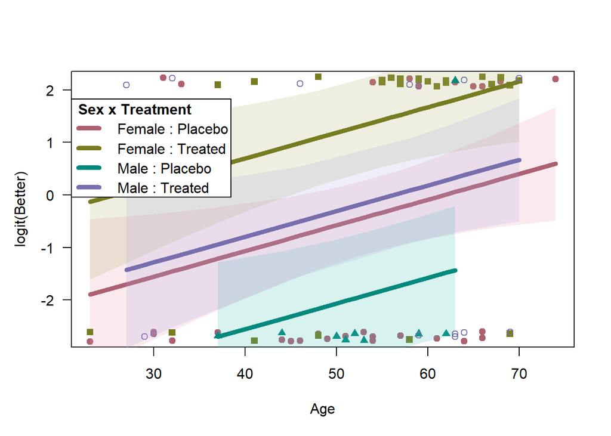

```r
library(vcd)
binreg_plot(arth.logistic2, type = "link")
```

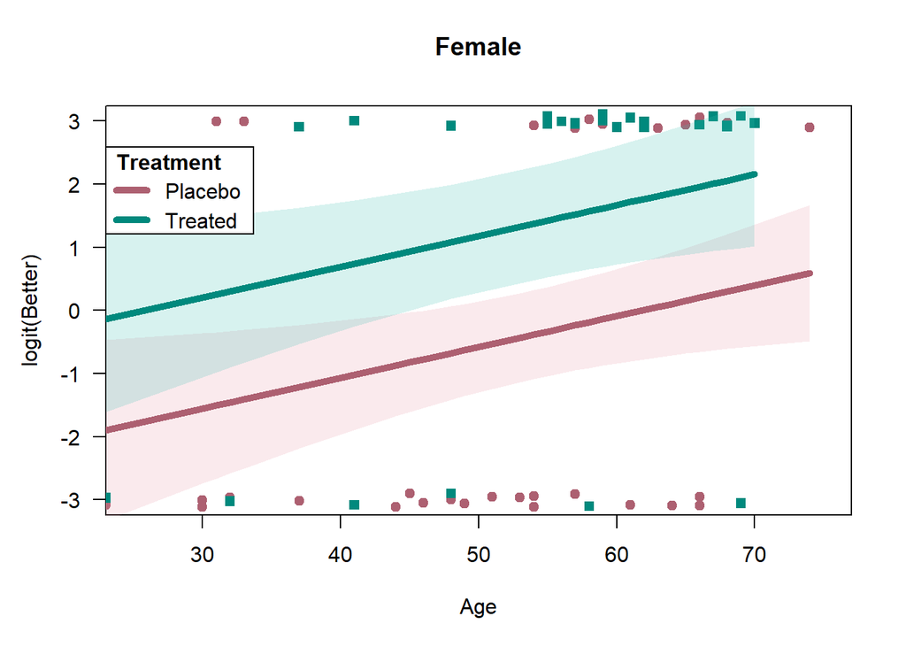

```r
binreg_plot(arth.logistic2, type = "link", subset = Sex == "Female", main = "Female", xlim = c(25,75), ylim = c(-3,3))
```

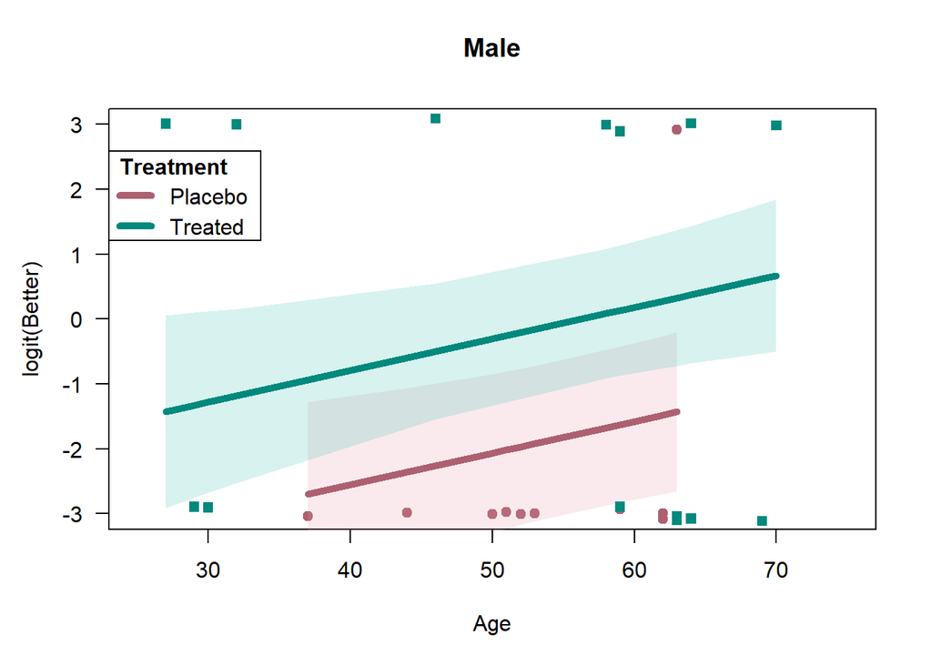

```r
binreg_plot(arth.logistic2, type = "link", subset = Sex == "Male", main = "Male", xlim = c(25,75), ylim = c(-3,3))
```

`binreg_plot`에서 `subset`옵션을 통해 원하는 변수의 수준만을 사용한 결과를 살펴볼 수 있다.  
`type = link`옵션은 독립변수 들의 결과를 선형형태로 반환하는 역할을 하기에 추정 회귀선이 직선이 나오는 것을 알 수 있다.

위의 그림의 경우, **Sex = Female**인 경우만을 고려하였고 아래 그림의 경우, **Sex = Male**인 경우만을 고려하였다.  
두 그림 모두 **Treatment = Treated**인 경우에 추정 회귀선이 더 높은 것(Better일 가능성이 높다.)을 알 수 있다.

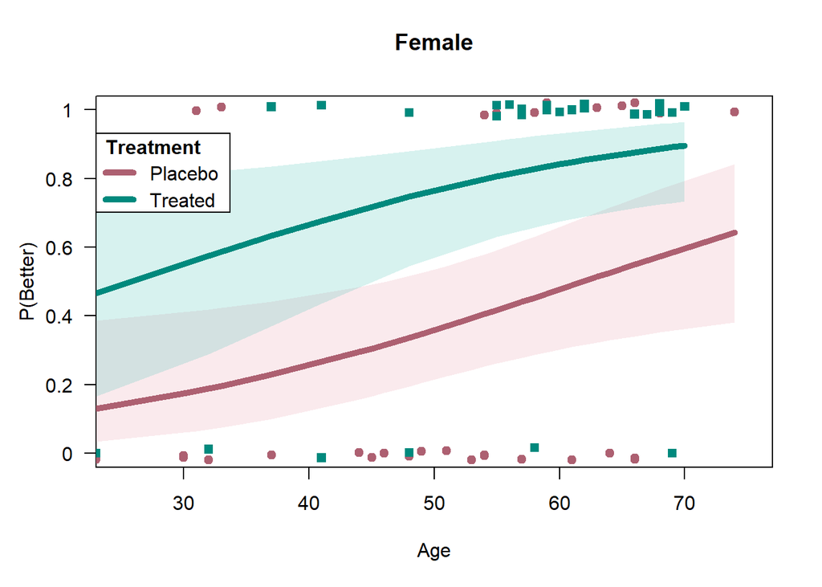

```r
binreg_plot(arth.logistic2, subset = Sex == "Female", main = "Female", xlim = c(25,75))
```

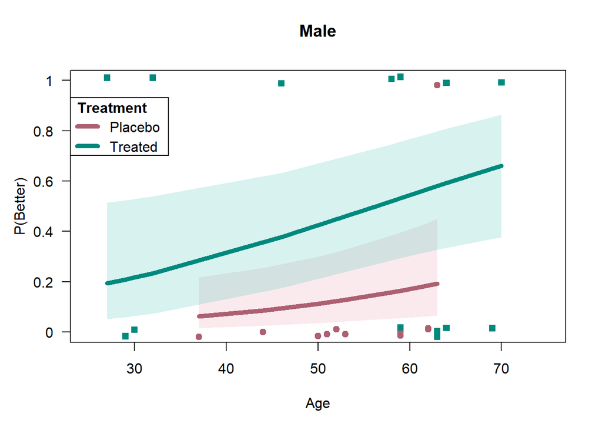

```r
binreg_plot(arth.logistic2, subset = Sex == "Male", main = "Male", xlim = c(25,75))
```

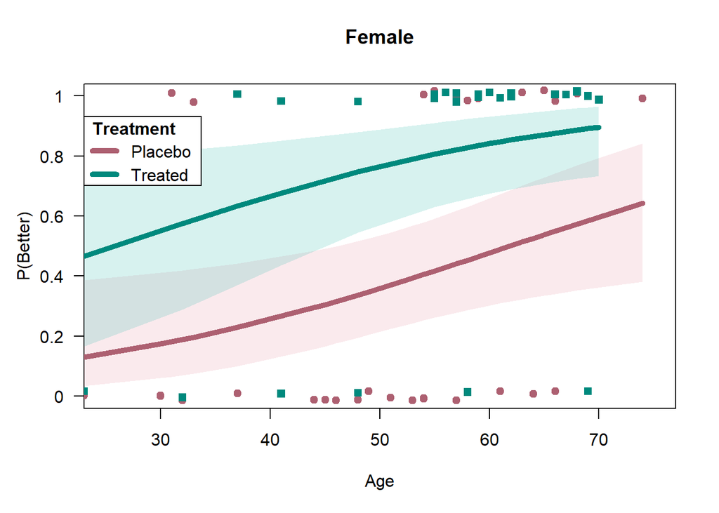

```r
binreg_plot(arth.logistic2, type = "response", subset = Sex == "Female", main = "Female", xlim = c(25,75))
```

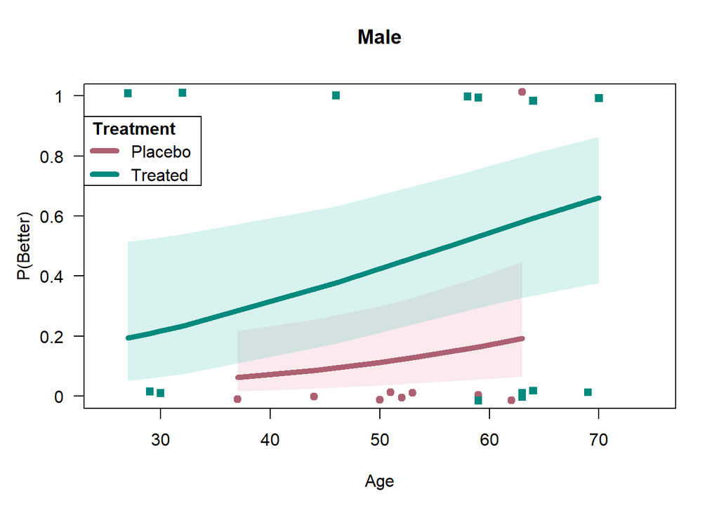

```r
binreg_plot(arth.logistic2, type = "response", subset = Sex == "Male", main = "Male", xlim = c(25,75))
```

`type = 'response'`로 지정하거나 아예 `type`을 지정해주지 않으면 위와 같이 0~1의 확률값을 가지는 곡선 형태의 추정 회귀선이 나오는 것을 확인할 수 있다.  
이는, `type = link`와는 다르게 선형적으로 가정하지 않고 설명변수들에 대한 반응변수 결과를 확률로 나타내기 때문이다.

앞선 결과와 동일하게, `type = response`로 설정하여도 **Sex = Male**, **Sex = Female**모두 **Treatment = Treated**의 추정 회귀선이 더 높은 곳에 있으며 나이가 증가함에 따라 1에 확률에 더 빠르게 수렴하는 것을 확인할 수 있다.

### 7.3.3 Effect plots

두 개 이상의 변수에서, 반응변수에 대한 모형 그림은 교호작용이 포함되어 있거나 주효과 또는 교호작용에 관심이 집중되어 다른 설명 변수를 제어할 때 번거로울 수 있다.  
**effects display**의 경우 이러한 문제에 대해 유용한 해결책이 될 수 있다. R에서는 `effects`패키지를 통해 사용할 수 있다.  
`effects`패키지는 선형 예측변수를 사용하는 다양한 통계 모형에 대해 그래픽 및 표 형식의 교호작용을 표시해주는 함수들을 제공한다.

**effects display**의 아이디어는 매우 간단하지만 매우 일반적이며 임의 복잡성의 모델을 처리한다.  
주어진 선형 모델 또는 일반화된 선형 모델에서 시각화하고자 하는 설명 변수의 특정 부분 집합을 고려하여 변수의 주효과와 교호작용을 포함하는 모든 적합치를 계산한다. 이때, 다른 모든 변수는 일반적인 값으로 고정됨으로써 제어된다.

#### 7.3.3.2 Partial residuals

이산형 반응 데이터의 경우 데이터를 적합된 관계와 함께 데이터가 있는 위치를 확인하는 것이 중요하다. **효과 패키지**에서는 부분 잔차를 표시할 수 있으므로 이러한 아이디어를 더욱 발전 시킬 수 있다.  
**부분 잔차**를 **effects display**에 추가하게되면 **비선형 관계 또는 생략된 교호작용**과 같은 연속형 설명 변수로 인한 반응 평균의 적합성 결여 또는 잘못 지정된 데이터를 확인하는데 도움이 된다.

*Example 7.8: Arthritis treatment*

```r
library(effects)
arth.eff2 <- allEffects(arth.logistic2, partial.residuals = TRUE)
names(arth.eff2)
```

```
## [1] "I(Age-50)" "Sex"       "Treatment"
```

`allEffects`는 모델에서 모든 고차항을 식별하고 반응변수의 예측된 확률을 계산할 수 있도록 도와주는 함수로, `effects`패키지에 포함돼있다.  
- `allEffectS(model,partial.residuals)`

- model; allEffects 함수를 적용할 모형
- partial.residuals: 부분 잔차 표시 여부

위의 코드는 **Age,Sex,Treatment**에 대한 반응변수의 예측된 확률을 계산한다.

```r
arth.eff2[["Sex"]]
```

```
##
##  Sex effect
## Sex
##    Female      Male
## 0.6093229 0.2605014
```

```r
arth.eff2[["Sex"]]$model.matrix
```

```
##   (Intercept) I(Age - 50) SexMale TreatmentTreated
## 1           1    3.357143       0        0.4880952
## 2           1    3.357143       1        0.4880952
## attr(,"assign")
## [1] 0 1 2 3
## attr(,"contrasts")
## attr(,"contrasts")$Sex
## [1] "contr.treatment"
##
## attr(,"contrasts")$Treatment
## [1] "contr.treatment"
```

**Sex**에 대한 주효과 매트릭스를 살펴본 결과 **Sex = Female**일 경우 **Sex**는 0의 값을 가지며, **Sex = Male**일 경우 **Sex**는 1의 값을 가지고 나머지 계수들은 동일한 값을 가지는 것을 확인할 수 있다.

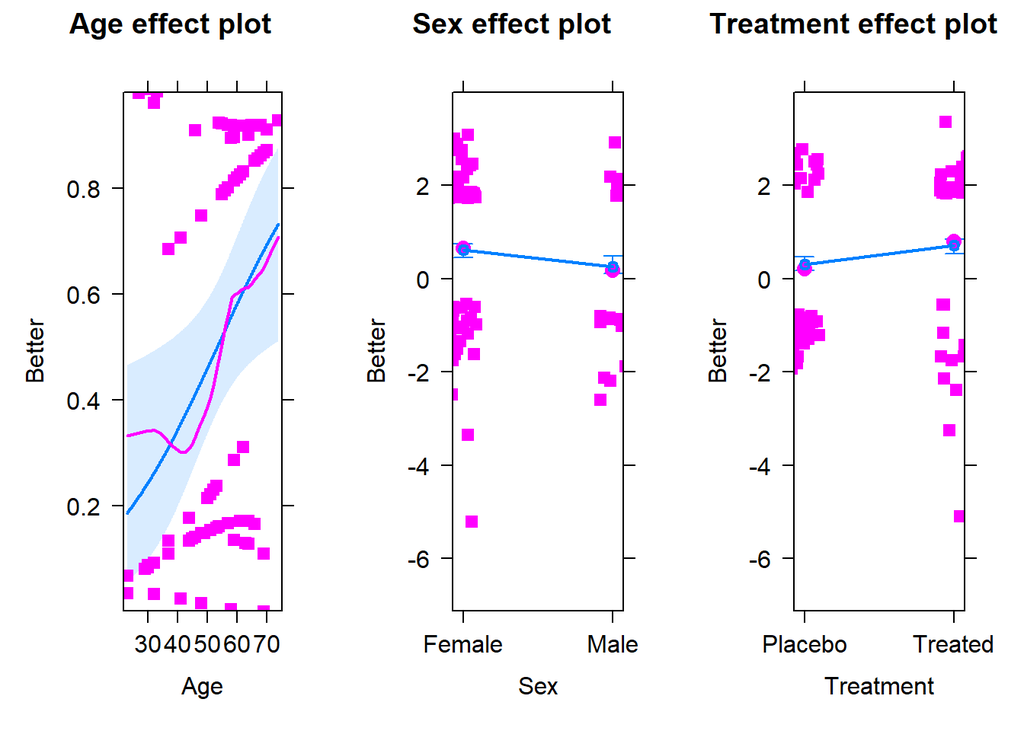

```r
plot(arth.eff2, rows = 1, cols = 3,
     type = "response", residuals.pch = 15)
```

`allEffects`의 결과를 **plot**으로 나타내게 되면 각 설명변수의 수준의 변화에 따른 **Better**에 대한 예측 확률의 변화를 시각적으로 살펴볼 수 있다.  
`Age effect plot`을 통해 **Age**가 증가할수록 **Better**에 대한 확률이 높아진다.(약의 효능이 있을 확률이 높다.)  
`Sex effect plot`을 통해 **Sex = Male**일 경우보다 **Sex = Female**일때 **Better**에 대한 확률이 높아진다.  
`Treatment effect plot`을 통해 **Treatment = Placebo**일 경우보다 **Treatment = Treated**일 경우에 **Better**에 대한 확률이 높아지는 것을 확인할 수 있다.

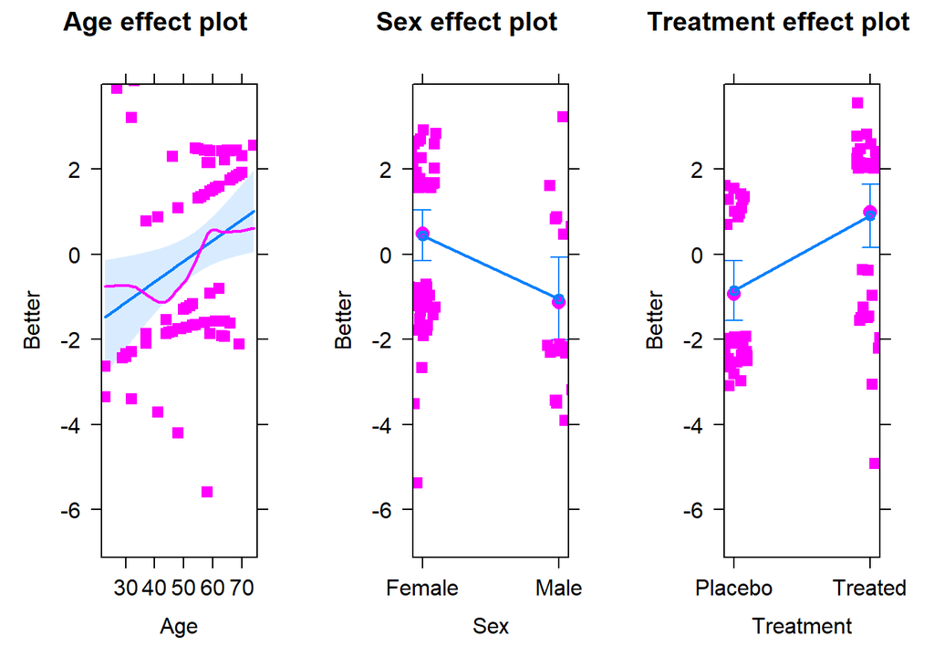

```r
plot(arth.eff2, rows = 1, cols = 3,
     type = "link", residuals.pch = 15)
```

`type = link`옵션을 사용하는 경우, `Sex effect plot`, `Treatment effect plot`에서 `type = response`를 지정했을 때 보다 변수의 수준에 따른 효과의 차이가 더 크게나는 것을 확인할 수 있다.

```r
arth.full <- Effect(c("Age", "Treatment", "Sex"),
                    arth.logistic2)
```

`Effect`함수의 경우 한 변수를 제어변수로 설정하고 그 제어 변수에 따른 나머지 변수들의 반응변수에 대한 수준 변화를 보여준다.  
`Effect`함수는 `effects`패키지에 포함돼있다.  
- `Effect(term,model)`

- term: 반응변수에 대한 수준 변화를 관찰할 변수들 (마지막 변수가 제어변수가 된다.)
- model: 변수들을 이용하여 적합시킨 모델

위의 코드에서는 `Effect`함수에서 마지막에 들어가는 변수를 **Sex**로 설정했으므로, **Sex**가 제어변수가 된다.

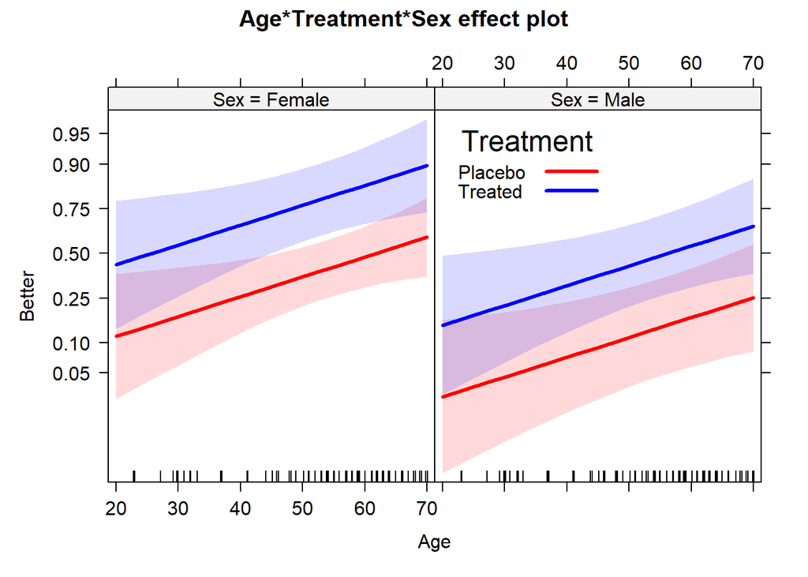

```r
plot(arth.full, multiline = TRUE, ci.style = "bands",
     colors = c("red", "blue"), lwd = 3,
     ticks = list(at = c(0.05, 0.1, 0.25, 0.5, 0.75, 0.9, 0.95)),
     key.args = list(x = 0.52, y = 0.92, columns = 1,
                     grid = TRUE)
     )
```

`Effect`를 사용하여 얻은 결과에 대해서 `plot`함수를 이용하여 시각화를 진행하면 위와 같다. **Sex**에 따라 패널 구별되는 것을 볼 수 있고, 앞선 결과들과 같이 **Sex = Female**일 때 **Treatment**의 수준에 상관없이 반응변수에 대한 확률이 **Sex = Male**일 때보다 모두 더 높게 나타나는 것을 것을 확인할 수 있다.

`multiline`옵션은 마지막 제어변수의 모든 수준의 조합을 고려하여 패널을 나눌지 혹은 제어변수의 각 수준만을 고려하여 패널을 나눌지 결정한다. **TRUE**로 지정하게 되면 제어변수의 각 수준만을 고려하여 패널을 나눈다.  
`ci.style`은 신뢰구간의 스타일을 결정하는 것으로 여기에서는 `bands`로 설정하여 각 회귀 적합선에 대한 95% 신뢰수준 **band**가 출력된다.

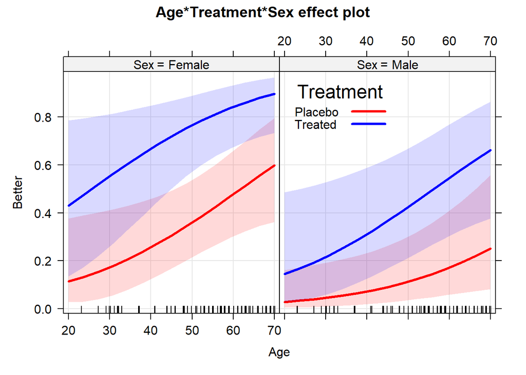

```r
plot(arth.full, multiline = TRUE, ci.style = "bands",
     type = "response",
     colors = c("red", "blue"), lwd = 3,
     key.args = list(x = .52, y = .92, columns = 1),
     grid = TRUE)
```

`type = response`로 지정하게 되면 적합선이 선형적인 직선이 아니라 0~1의 확률값을 가지는 곡선의 형태를 띄는 것을 확인할 수 있다.  
앞선 결과와 동일하게 **Sex = Female**인 경우 **Treatment**의 수준에 관계없이 **Sex = Male**보다 추정 회귀선이 항상 높은 값을 갖는 것을 알 수 있다.

## 7.4 Case studies

아래 예제는 다중 로지스틱 회귀 모델에서 데이터 분석, 모델 구축 및 시각화의 몇 가지 문제를 설명한다.  
우리는 주어진 모델을 해석하기 위한 데이터, 모델링 단계 및 그래프를 보기 위한 탐색 플롯의 조합에 초점을 맞춘다.

### 7.4.1 Simple models: Group comparisions and effect plots

*Example 7.9: Donner Party*

```r
data("Donner", package = "vcdExtra")
library(car)
some(Donner, 8)
```

```
##                       family age    sex survived      death
## Graves, Eleanor       Graves  15 Female        1       <NA>
## Graves, Jonathan      Graves   7   Male        1       <NA>
## Graves, Mary Ann      Graves  20 Female        1       <NA>
## Halloran, Luke         Other  25   Male        0 1846-08-25
## Keseberg, Ada       Keseberg   3 Female        0 1847-02-25
## Keyes, Sarah            Reed  70 Female        0 1846-05-29
## McCutchen, William McCutchen  30   Male        1       <NA>
## McCutchen, Harriet McCutchen   1 Female        0 1847-02-02
```

`Donner`데이터는 1847년 미국 시에라 네바다 산맥의 동쪽에서 발생한 눈보라에 대한 생존자 및 사망자에 대한 데이터로, `vcdExtra`패키지에 포함돼있다.

- row: 사람의 이름
- family: 가족 이름 (Factor variable - Other, Breen, Donner, Graves …)
- age: 나이 (Discrete variable)
- sex: 성별 (Factor variable - Male, Female)
- survived: 생존여부 (Factor variable - 0,1)
- death: 사망날짜 (POSIXct)

`car` 패키지는 대부분 선형 모델 및 일반화된 선형 모델에 대한 기능과 회귀진단, 특히 그래픽 진단을 할 수 있는 다양한 함수들을 제공한다.

```r
Donner$survived <- factor(Donner$survived, labels = c("no", "yes"))
```

**Survived**변수를 0 또는 1에서 **No,Yes**의 수준을 가지는 **Factor variable**로 바꿔주었다.

```r
xtabs(~ family, data = Donner)
```

```
## family
##     Breen    Donner      Eddy  FosdWolf    Graves  Keseberg McCutchen MurFosPik
##         9        14         4         4        10         4         3        12
##     Other      Reed
##        23         7
```

`xtabs`함수를 이용하여 `Donner`데이터의 **family**변수에 대한 빈도를 살펴보았다.  
`Donner`데이터에서, **기타(Other)**가 가장 많이 있으며, 그 다음으로는 **Donner**, **MurFosPik** 가족 순으로 많은 것을 확인할 수 있다.

```r
fam <- Donner$family
levels(fam)[c(3,4,6,7,9)] <- "Other"
```

```r
fam = factor(fam,levels(fam)[c(1, 2, 4:6, 3)])
Donner$family <- fam
xtabs(~family, data = Donner)
```

```
## family
##     Breen    Donner    Graves MurFosPik      Reed     Other
##         9        14        10        12         7        38
```

```r
xtabs(~ survived + family, data = Donner)
```

```
##         family
## survived Breen Donner Graves MurFosPik Reed Other
##      no      0      7      3         6    1    25
##      yes     9      7      7         6    6    13
```

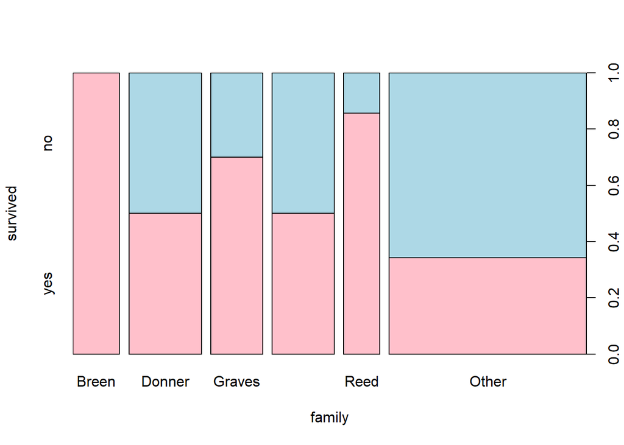

```r
plot(survived ~ family, data = Donner, col = c("pink", "lightblue"))
```

재구성한 가족 그룹에 대한 생존빈도를 살펴보기 위해 Plot을 그려 보았다.  
**Breen** 가족의 경우 모든 가족이 생존해 있는 것을 알 수 있었으며, **Donner**, **MurFosPik** 가족은 절반은 생존, 절반은 사망했고 **Reed** 가족은 1명 사망, 6명 생존인 것을 확인할 수 있었다.

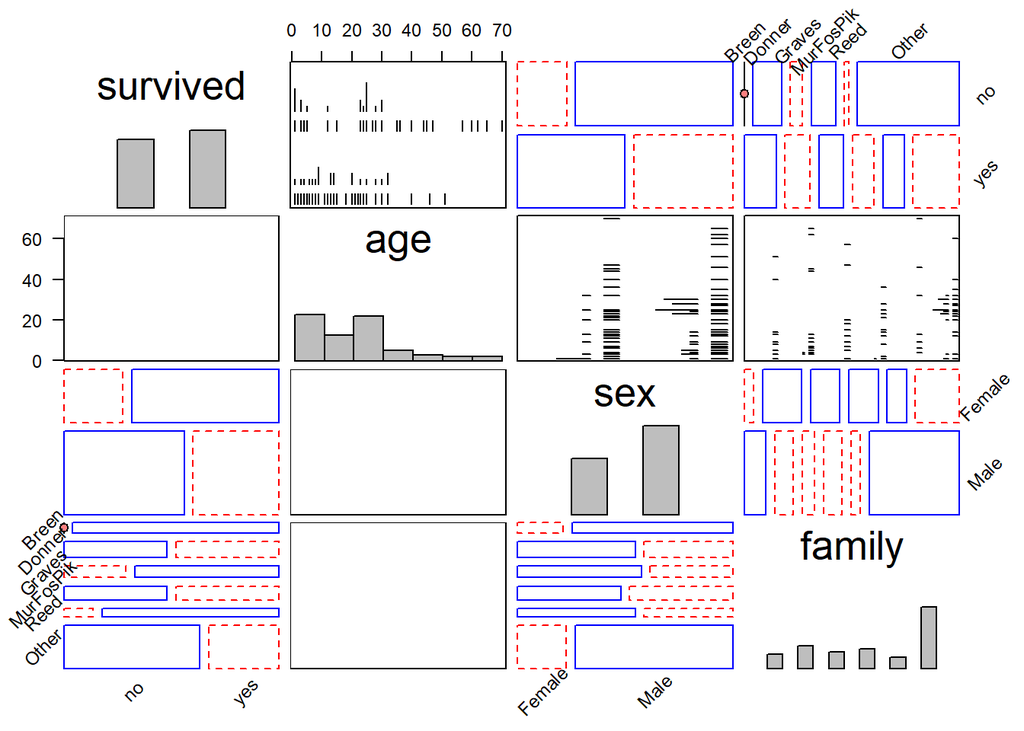

```r
library(gpairs)
library(vcd)
gpairs(Donner[,c(4,2,3,1)],
       diag.pars = list(fontsize = 20, hist.color = "gray"),
       mosaic.pars = list(gp = shading_Friendly),
       outer.rot = c(45,45))
```

`Donner`데이터에 대한 변수 간 패턴을 파악하기 위해 `gpairs`함수를 사용해 보았다.  
반응변수 **survived**는 **survived = yes**가 약간 빈도가 더 많긴 하지만 한 쪽으로 심하게 치우치는 문제는 발생하지 않은 것처럼 보인다.  
**Sex, Survived**의 모자이크 플롯을 살펴보면, **Sex = Male**일 때 **survived = Yes**는 음의 잔차를 가지는 것을 확인할 수 있고 **Sex = Female**일 때 **Survived = Yes**는 양의 잔차를 가지는 것을 확인할 수 있다.  
이를 통해, 성별이 남성인 경우 생존을 하지 못할 빈도가 높은 경향이 있고 성별이 여성인 경우 생존할 빈도가 높은 경향이 있는 것을 알 수 있다.

**family, Survived**의 모자이크 플롯을 살펴보면 앞선 결과와 동일하게 **Breen**가족만이 **Survived = Yes**일때 양의 잔차를 가지고 나머지 가족들은 **Survived = Yes**일때 음의 잔차를 가지는 것을 확인할 수 있다.

```r
gg <- ggplot(Donner, aes(age, as.numeric(survived == "yes"),
                         color = sex)) +
  ylab("Survived") +
  theme_bw() +
  geom_point(position = position_jitter(height = 0.02, width = 0))
```

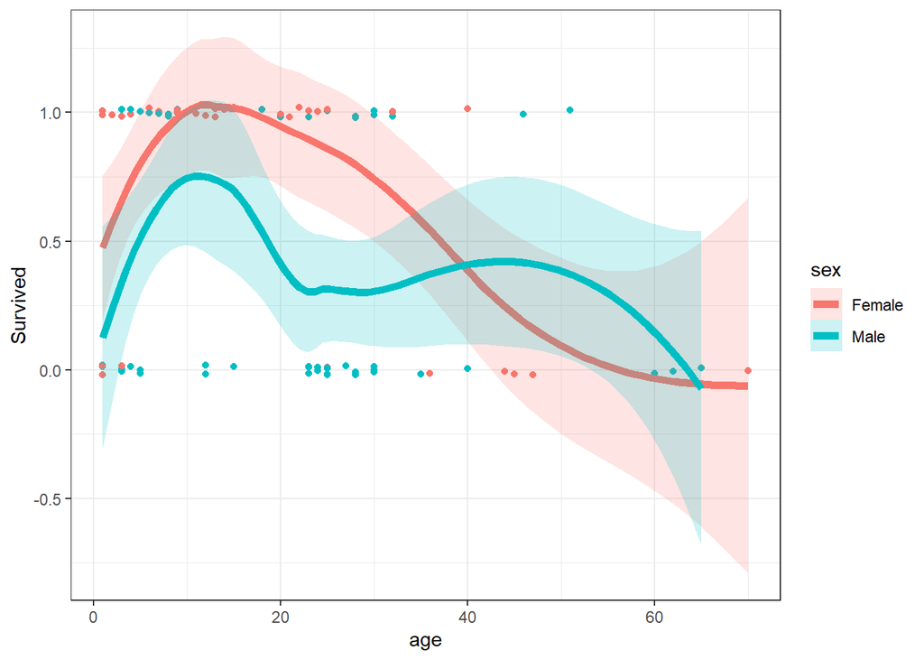

```r
gg + stat_smooth(methd = "glm", family = binomial,
                 formula = y ~ x,
                 alpha = 0.2,
                 size = 2,
                 aes(fill = sex))
```

**Age**를 x축으로 설정하고, **Survived**를 y축으로 설정한 후, 로지스틱 회귀모형에 적합시킨뒤, **sex**에 따른 생존율을 살펴보았다.  
**Age**가 40대 이하인 경우 **Sex = Female**의 생존율이 **Sex = Male**의 생존율보다 높았지만, **Age**가 40대 이상인 경우 **Sex = Male**의 생존율이 **Sex = Female**의 생존율보다 높아지는 것을 확인할 수 있었다.

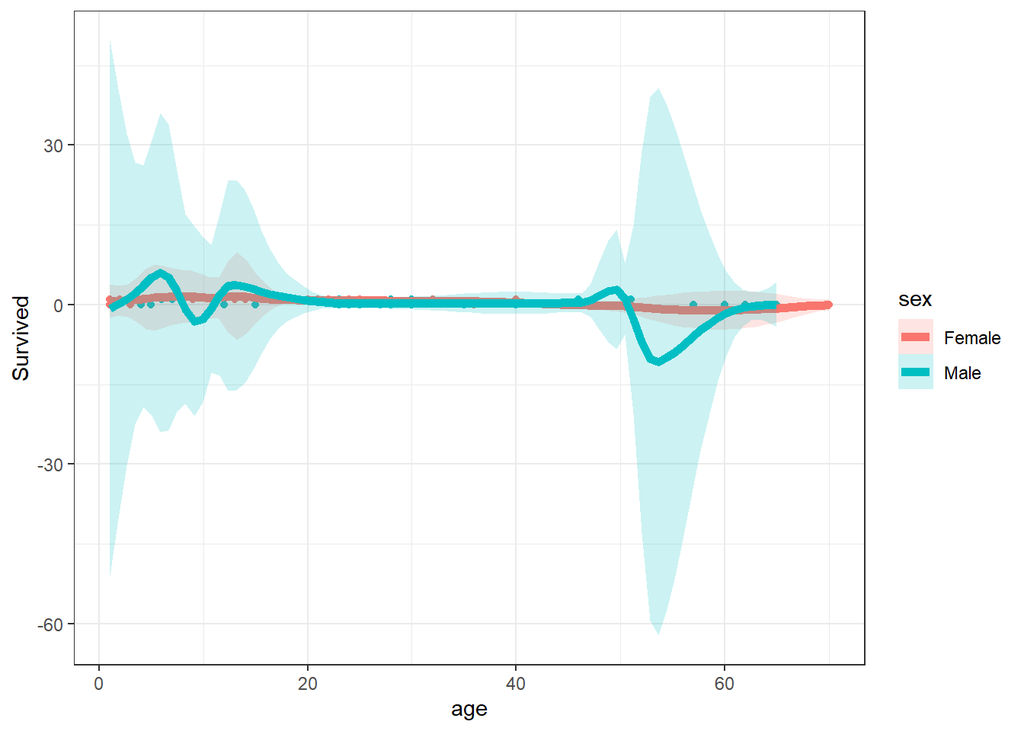

```r
gg + stat_smooth(metohd = "glm", family = binomial,
                 formula = y ~ poly(x,2), alpha = 0.2, size = 2,
                 aes(fill = sex))
```

`poly`함수를 사용하여 **Age**에 대한 2차 관계를 허용하여 그림을 다시 그려보았다. **2차 곡선**으로 그리게 될 경우, 앞서 살펴본 그림에 비해서 **Sex = Male**과 **Sex = Female**간의 확률차이가 현저히 줄어든 것을 확인할 수 있다.

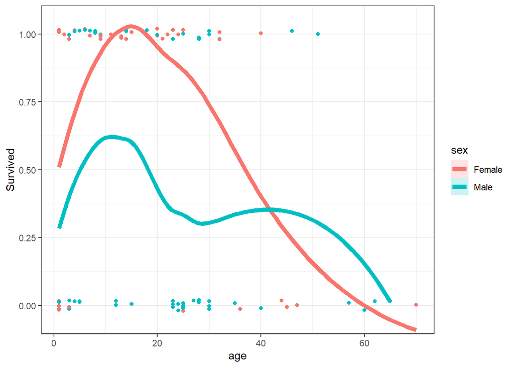

```r
gg + stat_smooth(metohd = "loess", span = 0.9,
                  alpha = 0.2, size = 2,
                 aes(fill = sex)) +
  coord_cartesian(ylim = c(-0.05, 1.05))
```

`metohd = "loess"`(비선형 곡선)를 이용하는 경우, `method = glm, family = binomial`과 같이 **Age**가 40대 이하에서 **Sex = Female**의 생존확률이 **Sex = Male**보다 높고 **Age**가 40대가 넘어가는 경우 **Sex = Male**의 생존확률이 **Sex = Female**의 생존확률보다 높아지는 것을 확인할 수 있다.

```r
donner.mod1 <- glm(survived ~ age + sex,
                   data = Donner, family = binomial)
Anova(donner.mod1)
```

```
## Analysis of Deviance Table (Type II tests)
##
## Response: survived
##     LR Chisq Df Pr(>Chisq)
## age   5.5182  1   0.018820 *
## sex   6.7274  1   0.009494 **
## ---
## Signif. codes:  0 '***' 0.001 '**' 0.01 '*' 0.05 '.' 0.1 ' ' 1
```

반응변수 **Survived**에 대한 **age, sex**를 설명변수로 하는 로지스틱 회귀 모형 적합 결과, 두 설명변수의 유의확률이 모두 유의수준 0.05보다 작으므로 귀무가설을 기각한다.  
따라서, 두 설명변수 **age, sex**는 계수가 0이 아니므로 유의한 설명변수라고 할 수 있다.

```r
donner.mod2 <- glm(survived ~ age * sex,
                   data = Donner, family = binomial)
Anova(donner.mod2)
```

```
## Analysis of Deviance Table (Type II tests)
##
## Response: survived
##         LR Chisq Df Pr(>Chisq)
## age       5.5182  1   0.018820 *
## sex       6.7274  1   0.009494 **
## age:sex   0.4003  1   0.526922
## ---
## Signif. codes:  0 '***' 0.001 '**' 0.01 '*' 0.05 '.' 0.1 ' ' 1
```

**age,sex**변수의 교호작용을 고려하기 위해 Formula를 **age*sex로 지정하였다.  
주효과 age,sex 변수는 유의확률이 유의수준 0.05보다 작으므로 유의하하다.  
두 변수의 교호작용(age:sex)**은 유의확률이 유의수준 0.05보다 크므로 귀무가설을 기각하지 못한다. 따라서, 계수가 0이므로 유의하지 않은 것을 확인할 수 있다.

```r
donner.mod3 <- glm(survived ~ poly(age, 2) + sex,
                   data = Donner, family = binomial)
Anova(donner.mod3)
```

```
## Analysis of Deviance Table (Type II tests)
##
## Response: survived
##              LR Chisq Df Pr(>Chisq)
## poly(age, 2)   9.9144  2   0.007033 **
## sex            8.0908  1   0.004449 **
## ---
## Signif. codes:  0 '***' 0.001 '**' 0.01 '*' 0.05 '.' 0.1 ' ' 1
```

**age**변수의 2차항을 고려하기 위해 `poly()`함수를 사용하였다.  
2차항을 적용한 결과, **poly(age,2),sex** 변수 모두 유의확률이 유의수준 0.05보다 작으므로 귀무가설을 기각한다. 따라서, 계수가 0이 아니라고 할 수 있으므로 유의한 변수임을 확인할 수 있었다.

```r
donner.mod4 <- glm(survived ~ poly(age,2) * sex,
                   data = Donner, family = binomial)
Anova(donner.mod4)
```

```
## Analysis of Deviance Table (Type II tests)
##
## Response: survived
##                  LR Chisq Df Pr(>Chisq)
## poly(age, 2)       9.9144  2   0.007033 **
## sex                8.0908  1   0.004449 **
## poly(age, 2):sex   8.9321  2   0.011492 *
## ---
## Signif. codes:  0 '***' 0.001 '**' 0.01 '*' 0.05 '.' 0.1 ' ' 1
```

**age의 2차항**과 **Sex**를 설명변수로 고려한 후, 두 변수의 교호작용을 살펴보았다.  
앞선 1차식들의 교호작용과는 달리, **age의 2차항과 Sex**의 교호작용의 유의확률은 유의수준 0.05보다 작으므로 귀무가설을 기각한다. 따라서 계수가 0이 아니므로 유의한 변수라고 할 수 있다.  
또한, **age의 2차항** 주효과인 **Sex**도 유의확률이 유의수준 0.05보다 작으므로 유의한 변수임을 확인할 수 있었다.

```r
library(vcdExtra)
LRstats(donner.mod1,donner.mod2,donner.mod3,donner.mod4)
```

```
## Likelihood summary table:
##                AIC    BIC LR Chisq Df Pr(>Chisq)
## donner.mod1 117.13 124.63  111.128 87    0.04159 *
## donner.mod2 118.73 128.73  110.727 86    0.03755 *
## donner.mod3 114.73 124.73  106.731 86    0.06439 .
## donner.mod4 109.80 124.80   97.799 84    0.14408
## ---
## Signif. codes:  0 '***' 0.001 '**' 0.01 '*' 0.05 '.' 0.1 ' ' 1
```

`LRstats()`함수를 사용하여 모델들의 주요 적합치를 비교해 보았다.  
**donner.mod1, donner.mod2는** 유의확률이 유의수준 0.05보다 낮으므로 변수를 추가하는것은 포화모델과 비교할 때, 유의한 잔차의 차이를 발생시키는 것임을 알 수 있다.  
반면, **donner.mod3,donner.mod4**는 유의확률이 유의수준 0.05보다 높으므로 포화모델에 가까운 모델임(변수를 추가했을때, 유의한 잔차의 차이가 발생하지 않음.)을 확인할 수 있었다.

```r
mods <- list(donner.mod1, donner.mod2, donner.mod3, donner.mod4)
LR <- sapply(mods, function(x) x$deviance)
LR <- matrix(LR,2,2)
rownames(LR) <- c("additive", "non-add")
colnames(LR) <- c("linear", "non-lin")
LR <- cbind(LR, diff = LR[,1] - LR[,2])
LR <- rbind(LR, diff = c(LR[1,1:2] - LR[2,1:2], NA))
LR
```

```
##              linear    non-lin      diff
## additive 111.127504 106.731334  4.396171
## non-add  110.727180  97.799206 12.927974
## diff       0.400324   8.932128        NA
```

LR통계량을 추출하여 행 및 열의 차이를 함께 표에 배열해서 모형을 비교해 보았다.  
결과적으로, **Survived**와 **Age**와의 관계가 **Sex = Male**과 **Sex = Female**에 따라 다르다는 증거가 있지만 선형적인 로지스틱에 의해서 잘 설명되지는 않는것을 확인할 수 있다(잔차의 차이가 크지 않기 때문이다.).

```r
library(splines)
donner.mod5 <- glm(survived ~ ns(age,2) * sex,
                   data = Donner, family = binomial)
Anova(donner.mod5)
```

```
## Analysis of Deviance Table (Type II tests)
##
## Response: survived
##                LR Chisq Df Pr(>Chisq)
## ns(age, 2)       9.2813  2   0.009651 **
## sex              7.9778  1   0.004735 **
## ns(age, 2):sex   8.7058  2   0.012869 *
## ---
## Signif. codes:  0 '***' 0.001 '**' 0.01 '*' 0.05 '.' 0.1 ' ' 1
```

단순성을 위해 2차 효과인 `poly()`함수가 아닌 `splines`패키지의 `ns()`함수를 사용하여 스플라인을 사용하여 다시 한 번 분석을 진행해 보았다.  
`splines`패키지는 `spline`을 하기 위한 다양한 함수를 제공하며 그 중 `ns`는 **natural cubic spline**을 생성할 수 있게 도와주는 함수이다.

`ns(age,2)`를 통해 spline을 적용하여 분석을 진행한 결과, **주효과와 교호작용** 모두 유의확률이 유의수준 0.05보다 작으므로 유의한 변수인 것을 확인할 수 있다.

```r
donner.mod6 <- glm(survived ~ ns(age,4) * sex,
                   data = Donner, family = binomial)
Anova(donner.mod6)
```

```
## Analysis of Deviance Table (Type II tests)
##
## Response: survived
##                LR Chisq Df Pr(>Chisq)
## ns(age, 4)      22.0482  4   0.000196 ***
## sex             10.4912  1   0.001199 **
## ns(age, 4):sex   8.5404  4   0.073672 .
## ---
## Signif. codes:  0 '***' 0.001 '**' 0.01 '*' 0.05 '.' 0.1 ' ' 1
```

`ns(age,4)`를 사용하여 **age**변수를 4차 스플라인의 형태로 만들어 로지스틱 회귀분석을 진행한 결과, **주효과들**은 유의확률이 유의수준 0.05보다 작으므로 유의하게 나타나지만, **교호작용**은 유의확률이 유의수준 0.05보다 크므로 유의하지 않은 것을 확인할 수 있다.

```r
LRstats(donner.mod4, donner.mod5, donner.mod6)
```

```
## Likelihood summary table:
##                AIC    BIC LR Chisq Df Pr(>Chisq)
## donner.mod4 109.80 124.80   97.799 84     0.1441
## donner.mod5 110.66 125.66   98.659 84     0.1310
## donner.mod6 106.06 131.06   86.057 80     0.3016
```

**donner.mod4, donner.mod5, donner.mod6** 모두 유의확률이 유의수준 0.05보다 크므로 귀무가설을 기각하지 못한다. 즉, 주어진 모형에 변수를 추가시키는 것은 유의한 잔차의 차이를 발생시키지 못한다는 것을 알 수 있다.  
따라서, `spline`을 이용하여 모형을 적합시키는 것은 적절한 방법이 아닌 것을 확인할 수 있다.

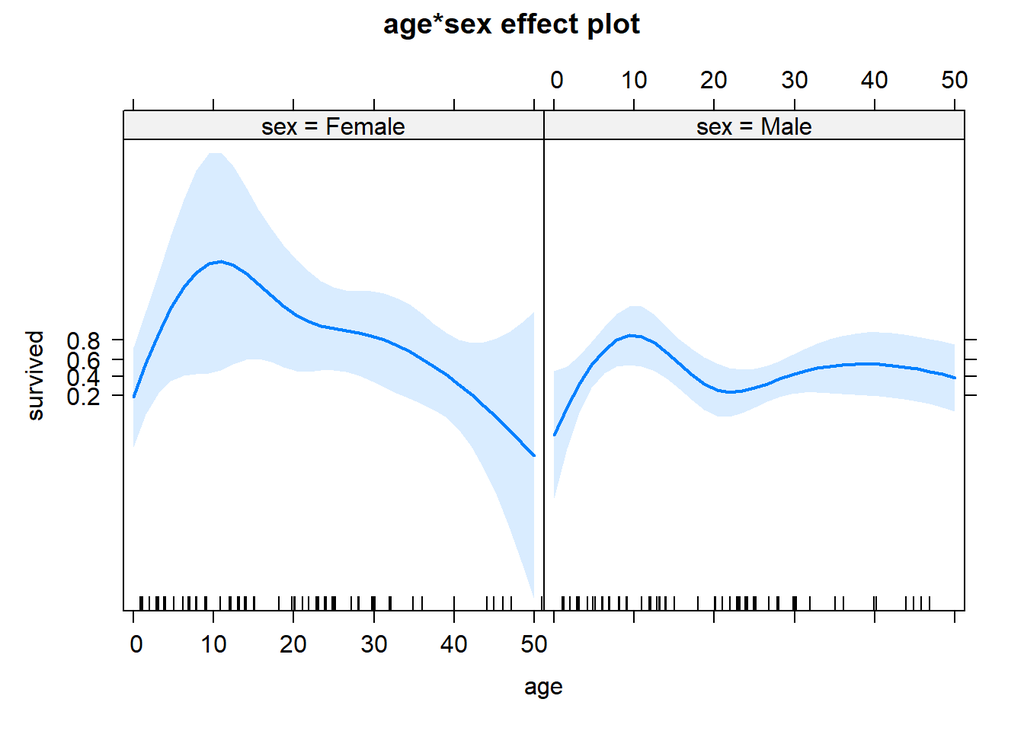

```r
library(effects)
donner.eff6 <- allEffects(donner.mod6, xlevels = list(age = seq(0,50,5)))
plot(donner.eff6, tickcs = list(at=c(0.001, 0.01, 0.05, 0.1, 0.25,0.5,0.75,0.9,0.95,0.99,0.999)))
```

**donner.mod6**를 이용하여 *effects plot*을 그려보았다. **Sex = Female**의 경우, 0-15세 사이에서 생존확률이 가장 높았고 **Age**가 증가할수록 생존확률이 점점 떨어지는 것을 확인할 수 있었다.  
**Sex = Male**의 경우, **Age**가 0-15세 사이에서 생존확률이 가장 높았고 **Age**가 15-25세 생존확률이 전반적으로 낮았지만, **Age**가 25세 이후부터 생존확률이 다시 조금씩 증가하는 것을 볼 수 있다.

*Example 7.10: Racial profiling: Arrests for marijuana possession*

```r
library(effects)
data("Arrests", package = "effects")
Arrests[sample(nrow(Arrests),6),]
```

```
##      released colour year age    sex employed citizen checks
## 428       Yes  White 2000  31   Male      Yes     Yes      0
## 1942      Yes  Black 2000  20   Male       No     Yes      4
## 2207      Yes  White 2000  17   Male       No     Yes      1
## 1853      Yes  White 2000  37   Male      Yes     Yes      0
## 797       Yes  Black 1999  15   Male      Yes     Yes      2
## 4234      Yes  White 1998  16 Female       No     Yes      3
```

`Arrests`데이터는 토론토 경찰에 의한 인종 프로파일링 가능성에 대한 조사 데이터로 `effects`패키지에 포함돼있다.  
신문이 분석한 대마초 소지 혐의로 5,226건의 구속 기록을 담고 있으며, 반응 변수는 **released**로 주요 설명 변수는 체포된 사람의 피부색이다.

- released: 구속된 사람이 소환장과 함께 풀려났는지에 대한 여부 (Factor variable - No, Yes)
- colour: 체포자의 인종 (Factor variable - White, Black)
- year: 년도 (Discrete variable)
- age: 나이 (Discrete variable)
- sex: 성별 (Factor variable - Male, Female)
- employed: 고용상태 (Factor variable - No,Yes)
- citizen: 시민여부 (Factor variable - No,Yes)
- checks: 체포인의 이름이 나타난 경찰 데이터 베이스 수 (Discrete variable)

```r
Arrests$year <- as.factor(Arrests$year)
arrests.mod <- glm(released ~ employed + citizen + checks +
                     colour*year + colour*age,
                   family = binomial, data = Arrests)
```

**year**변수를 **factor**의 형태로 변환해 준 후, **released**를 반응변수로하고 **employed, citizen, checks, colour & year의 교호작용, Colour & age의 교호작용**을 설명변수로 하는 로지스틱 회귀모형을 적합시켰다.

```r
Anova(arrests.mod)
```

```
## Analysis of Deviance Table (Type II tests)
##
## Response: released
##             LR Chisq Df Pr(>Chisq)
## employed      72.673  1  < 2.2e-16 ***
## citizen       25.783  1  3.820e-07 ***
## checks       205.211  1  < 2.2e-16 ***
## colour        19.572  1  9.687e-06 ***
## year           6.087  5  0.2978477
## age            0.459  1  0.4982736
## colour:year   21.720  5  0.0005917 ***
## colour:age    13.886  1  0.0001942 ***
## ---
## Signif. codes:  0 '***' 0.001 '**' 0.01 '*' 0.05 '.' 0.1 ' ' 1
```

로지스틱 회귀분석 결과, **year,age**를 제외한 모든 설명변수들의 유의확률이 유의수준 0.05보다 작으므로 귀무가설을 기각하여 유의한 설명변수임을 확인할 수 있었다.  
특히, **colour:year**, **colour:age**의 교호작용 또한 유의한 변수임을 알 수 있다.

```r
lmtest::coeftest(arrests.mod)
```

```
##
## z test of coefficients:
##
##                        Estimate Std. Error  z value  Pr(>|z|)
## (Intercept)           0.3444334  0.3100749   1.1108 0.2666514
## employedYes           0.7350645  0.0847701   8.6713 < 2.2e-16 ***
## citizenYes            0.5859841  0.1137717   5.1505 2.598e-07 ***
## checks               -0.3666425  0.0260322 -14.0842 < 2.2e-16 ***
## colourWhite           1.2125167  0.3497751   3.4666 0.0005272 ***
## year1998             -0.4311794  0.2603589  -1.6561 0.0977023 .
## year1999             -0.0944343  0.2615447  -0.3611 0.7180519
## year2000             -0.0108975  0.2592073  -0.0420 0.9664655
## year2001              0.2430630  0.2630151   0.9241 0.3554129
## year2002              0.2129549  0.3532786   0.6028 0.5466444
## age                   0.0287279  0.0086191   3.3330 0.0008590 ***
## colourWhite:year1998  0.6519565  0.3134898   2.0797 0.0375555 *
## colourWhite:year1999  0.1559504  0.3070430   0.5079 0.6115161
## colourWhite:year2000  0.2957537  0.3062034   0.9659 0.3341076
## colourWhite:year2001 -0.3805413  0.3040538  -1.2516 0.2107305
## colourWhite:year2002 -0.6173178  0.4192551  -1.4724 0.1409086
## colourWhite:age      -0.0373729  0.0102003  -3.6639 0.0002484 ***
## ---
## Signif. codes:  0 '***' 0.001 '**' 0.01 '*' 0.05 '.' 0.1 ' ' 1
```

`lmtest`패키지의 `coeftest`를 통해 변수들의 계수 추정치 및 Wald검정 결과를 확인할 수 있다.  
**Employed, citizen, checks, colour, age, colourwhite:year1998, colourwhite:age**변수들은 유의확률이 유의수준 0.05보다 작으므로 귀무가설을 기각하여 유의한 설명변수임을 알 수 있다.

특히, 앞선 결과에서 **age**변수는 유의하지 않게 나왔는데 앞선 검정은 **age**를 주효과가 아닌 교호작용의 일부로 인식한 후 검정을 진행하였고 **Wald**검정은 **age**를 주효과로 인식한 후 검정을 진행하였기 때문에 유의한 결과가 나온 것으로 생각된다.

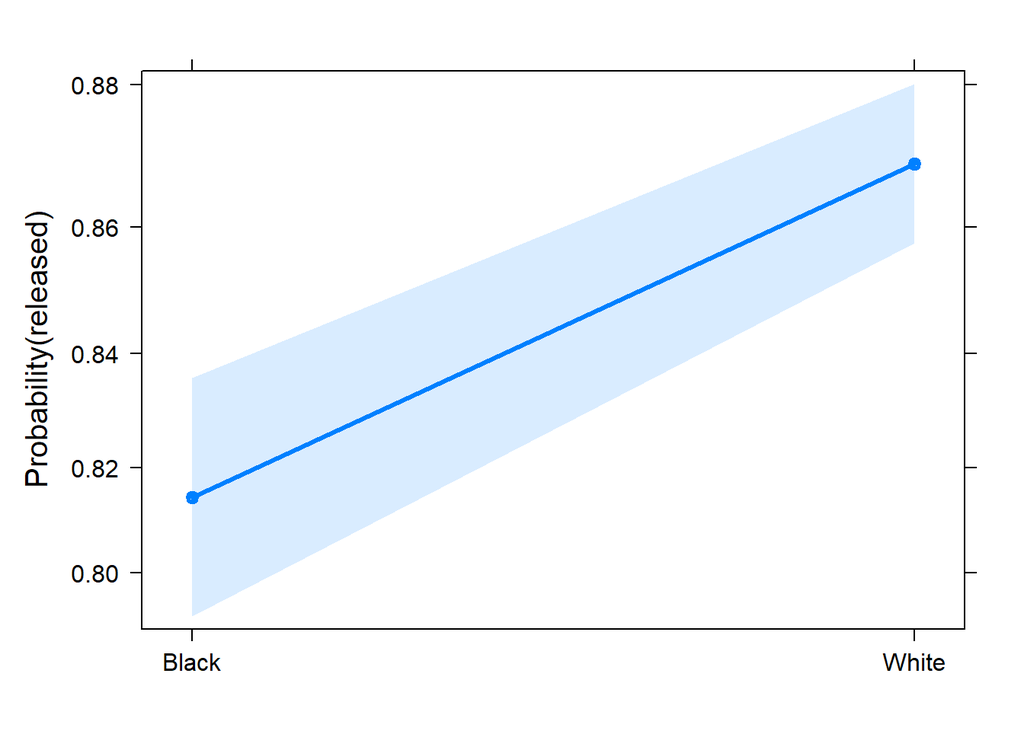

```r
plot(Effect("colour", arrests.mod),
     lwd = 3, ci.style = "bands", main = "",
     xlab = list("Skin color of arrestee", cex = 1.25),
     ylab = list("Probability(released)", cex = 1.25))
```

**relased**에 대한 **colour = White**의 확률이 **colour = Black**보다 높은 것으로 보아 흑인에 비해 백인은 심한대우를 덜 받은 것을 확인할 수 있다.

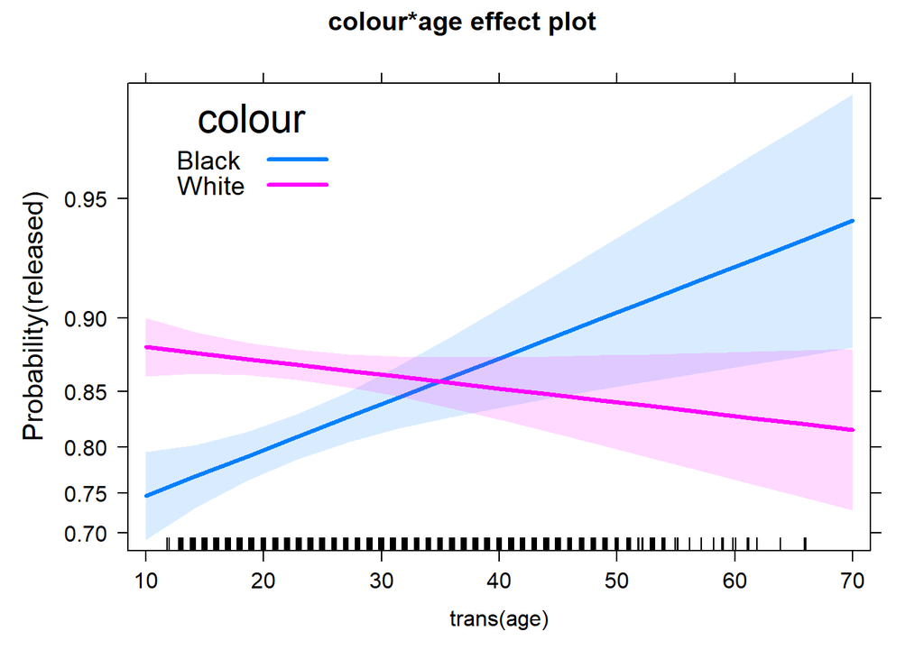

```r
plot(Effect(c("colour", "age"), arrests.mod),
     lwd = 3, multiline = TRUE, ci.style = "bands",
     xlab = list("Age", cex = 1.25),
     ylab = list("Probability(released)", cex = 1.25),
     key.args = list(x = 0.05, y = 0.99, cex = 1.2, columns=1))
```

**Age**와 같이 고려하여 **Effect display**를 살펴본 결과, **Age**가 30대 이하인 젊은 흑인의 경우 동등한 나이의 백인에 비해 더 심한대우를 받았지만 **Age**가 많아짐에 따라 오히려 흑인이 백인에 비해 심한대우를 덜 받은 것을 확인할 수 있다.

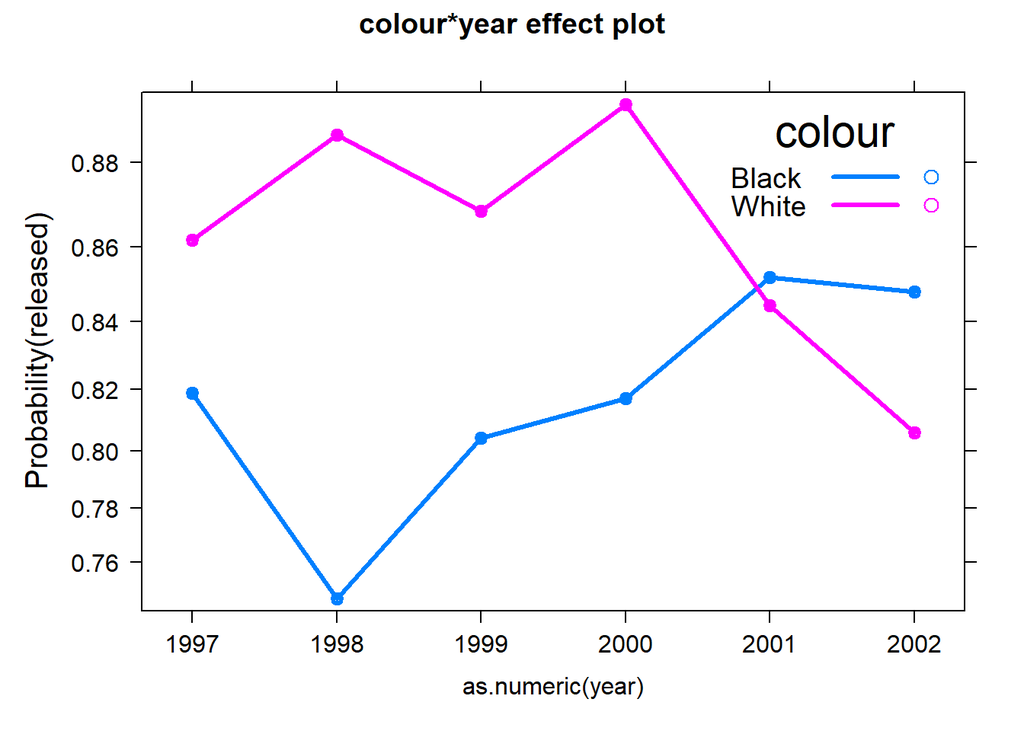

```r
plot(Effect(c("colour","year"), arrests.mod),
     lwd = 3, multiline = TRUE,
     xlab = list("Year", cex = 1.25),
     ylab = list("Probability(released)", cex = 1.25),
     key.args = list(x = 0.7, y = 0.99, cex = 1.2, columns = 1))
```

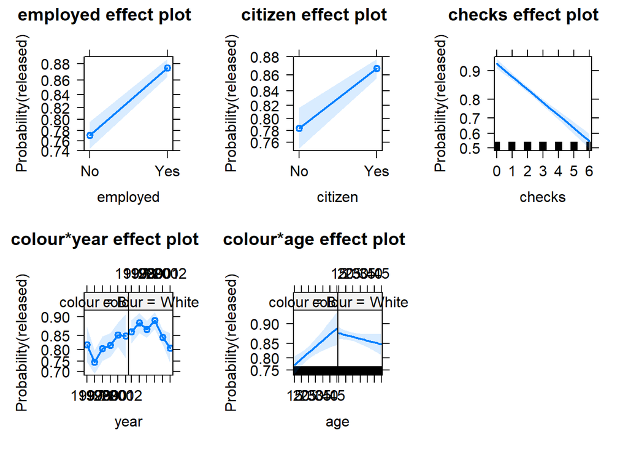

```r
arrests.effects <- allEffects(arrests.mod,
                              xlevels = list(age = seq(15,45,5)))
plot(arrests.effects,
     ylab = "Probability(released)",
     ci.style = "bands", ask = FALSE)
```

`allEffects`함수를 사용하여 시각화를 하게 되면 각 설명변수의 수준 혹은 값이 변화함에 따라 반응변수에 대한 확률 변화를 한 패널안에서 확인할 수 있다. **Employed = Yes**인 경우, **Employed = No**인 사람에 비해 심한대우를 덜 받았음을 알 수 있고 **Citizen = Yes**인 경우, **Citizen = No**인 사람에 비해 심한대우를 덜 받았으며, **checks**가 낮을수록 심한대우를 덜 받았던 것을 확인할 수 있다.

### 7.4.2 More complex models: Model selection and visualization

*Example 7.11: Death in the ICU*

```r
data("ICU", package = "vcdExtra")
names(ICU)
```

```
##  [1] "died"     "age"      "sex"      "race"     "service"  "cancer"
##  [7] "renal"    "infect"   "cpr"      "systolic" "hrtrate"  "previcu"
## [13] "admit"    "fracture" "po2"      "ph"       "pco"      "bic"
## [19] "creatin"  "coma"     "white"    "uncons"
```

`ICU` 데이터 세트는 호스머, 레메쇼와 스투르디반트와 프렌들리에서 도출된 성인 중환자실 입원후 환자의 생존에 대한 훨씬 더 큰 연구의 일부인 200명의 피험자 샘플로 구성되 있으며, `vcdExtra`패키지에 포함돼있다.  
이 연구의 목표는 환자의 병원 퇴원 시 생존 확률을 예측하고 ICU 사망률과 관련된 위험 요인을 연구하는 로지스틱 회귀 모델을 개발하는 것이었다.

- died: 퇴원 전 사망여부 (Factor variable - No, Yes)
- age: 나이 (Discrete variable)
- sex: 성별 (Factor variable - Female, Male)
- race: 환자의 인종 (Factor variable - Black, Other, White)
- service: ICU 입원 서비스 (Factor variable - Medical, Surgical)
- cancer: 현재 문제가 암인지에 대한 여부 (Factor variable - No, Yes)
- renal: 만성 신부전 병력 여부 (Factor variable - No, Yes)
- infect: 중환자실 입원 시 감염 가능성 여부 (Factor variable - No, Yes)
- cpr: 중환자실 입원 전 cpr 여부 (Factor variable - No, Yes)
- systolic: 입원 시 수축기 혈압 (Discrete variable)
- hrtrate: 심박수 (Discrete variable)
- previcu: 6개월 이내에 ICU에 입원한 적 있는지에 대한 여부 (Factor variable - No, Yes)
- admit: 입원 유형 (Factor variable - Elective, Emergency)
- fracture: 고관절 골절 관련 입원 여부 (Factor variable - No, Yes)
- po2: 시작 혈액 가스의 PO2수치 (Factor variable - >60, <=60)
- ph: 시작 혈액 가스의 PH수치 (Factor variable - >=7.25, <7.25)
- pco: 시작 혈액 가스의 PCO2수치 (Factor variable - <=45, >45)
- bic: 시작 혈액 가스의 Bicarbonate수치 (Factor variable - >=18, <18)
- creatin: 시작 혈액 가스의 Creatin수치 (Factor variable - <=2, >2)
- coma: 중환자실에 입원 했을 때 의식 수준 (Factor variable - None, Stupor Coma)
- white: race 변수의 재코딩 (Factor variable - White, Non-White)
- uncons: coma 변수의 재코딩 (Factor variable - No, Yes)

```r
ICU <- ICU[,-c(4,20)]
```

`ICU`데이터에서 **race**와 **coma**는 재코딩된 변수가 존재하기 때문에 각각 2개의 변수를 가지고 있다.  
따라서, 변수가 겹치지않도록 두 개의 변수 중 각각 하나씩 제거한 후, 분석을 진행한다.

```r
icu.full <- glm(died ~., data = ICU, family = binomial)
summary(icu.full)
```

```
##
## Call:
## glm(formula = died ~ ., family = binomial, data = ICU)
##
## Deviance Residuals:
##      Min        1Q    Median        3Q       Max
## -1.80396  -0.56064  -0.20440  -0.08635   2.97729
##
## Coefficients:
##                  Estimate Std. Error z value Pr(>|z|)
## (Intercept)     -6.726704   2.385512  -2.820  0.00481 **
## age              0.056393   0.018624   3.028  0.00246 **
## sexMale          0.639725   0.531393   1.204  0.22864
## serviceSurgical -0.673522   0.601902  -1.119  0.26315
## cancerYes        3.107051   1.045846   2.971  0.00297 **
## renalYes        -0.035708   0.801647  -0.045  0.96447
## infectYes       -0.204933   0.553191  -0.370  0.71104
## cprYes           1.053483   1.006614   1.047  0.29530
## systolic        -0.015472   0.008497  -1.821  0.06864 .
## hrtrate         -0.002769   0.009607  -0.288  0.77317
## previcuYes       1.131942   0.671450   1.686  0.09183 .
## admitEmergency   3.079583   1.081584   2.847  0.00441 **
## fractureYes      1.411402   1.029705   1.371  0.17047
## po2<=60          0.073822   0.857044   0.086  0.93136
## ph<7.25          2.354078   1.208804   1.947  0.05148 .
## pco>45          -3.018442   1.253448  -2.408  0.01604 *
## bic<18          -0.709284   0.909777  -0.780  0.43561
## creatin>2        0.295143   1.116925   0.264  0.79159
## whiteNon-white   0.565729   0.926828   0.610  0.54160
## unconsYes        5.232292   1.226303   4.267 1.98e-05 ***
## ---
## Signif. codes:  0 '***' 0.001 '**' 0.01 '*' 0.05 '.' 0.1 ' ' 1
##
## (Dispersion parameter for binomial family taken to be 1)
##
##     Null deviance: 200.16  on 199  degrees of freedom
## Residual deviance: 120.78  on 180  degrees of freedom
## AIC: 160.78
##
## Number of Fisher Scoring iterations: 6
```

**반응변수(died)**를 제외한 모든 데이터를 설명변수로 사용하여 로지스틱 회귀 분석을 진행하였다.  
**age, cancerYes, admit, pco, uncons**변수는 유의확률이 유의수준 0.05보다 작으므로 귀무가설을 기각하게 된다. 따라서, 유의한 변수임을 알 수 있다.  
그 외의 설명변수들은 유의확률이 유의수준 0.05보다 크므로 귀무가설을 기각하지 못하게된다. 따라서, 유의하지 않은 변수임을 확인할 수 있다.

```r
LRtest <- function(model){
  c(LRchisq = (model$null.deviance - model$deviance),
    df = (model$df.null - model$df.residual))
}
(LR <- LRtest(icu.full))
```

```
##  LRchisq       df
## 79.38262 19.00000
```

```r
(pvalue <- 1 - pchisq(LR[1],LR[2]))
```

```
##      LRchisq
## 2.375397e-09
```

우리가 적합시킨 `icu.full`모델의 L0와 L1잔차 비교를 통해 모형의 적합도 검정을 진행해 보았다.  
L0-L1의 검정통계량 값은 79.38262으로 카이제곱 분포를 따르며, 유의확률이 유의수준 0.05보다 작으므로 귀무가설을 기각한다.  
따라서, 기존 모델에 변수를 추가하여 적합된 `icu.full`모델은 적합한 모형임을 확인할 수 있다.

```r
icu.full1 <- update(icu.full, . ~ . - renal - fracture)
anova(icu.full1, icu.full, test = "Chisq")
```

```
## Analysis of Deviance Table
##
## Model 1: died ~ age + sex + service + cancer + infect + cpr + systolic +
##     hrtrate + previcu + admit + po2 + ph + pco + bic + creatin +
##     white + uncons
## Model 2: died ~ age + sex + service + cancer + renal + infect + cpr +
##     systolic + hrtrate + previcu + admit + fracture + po2 + ph +
##     pco + bic + creatin + white + uncons
##   Resid. Df Resid. Dev Df Deviance Pr(>Chi)
## 1       182     122.48
## 2       180     120.78  2   1.6994   0.4275
```

`update`함수를 통해 전체 모델에서 **renal, fracture**를 제거한 후 로지스틱 회귀모형을 다시 한 번 적합시켜 보았다.  
anova 검정결과, **renal, fracture**를 제외한 모델과 제외하지 않은 모델간 잔차의 차이는 약 1.7로 매우 작으며, 유의확률이 유의수준 0.05보다 크므로 귀무가설을 기각하지 못한다. 따라서, **renal, fracture**를 제거 하는 것은 모형에 대해서 유의한 잔차의 차이를 만들어내지 못한다고 할 수 있다.

```r
library(rms)
dd <- datadist(ICU[,-1])
options(datadist = "dd")
icu.lrm1 <- lrm(died ~ ., data = ICU)
icu.lrm1 <- update(icu.lrm1, . ~ . - renal - fracture)
```

모델 선택을 고려하기 전에 계수 및 중요도 테스트 표를 보는 것보다 모델에 대해서 시각적으로 살펴보는 것이 더 유용하다.  
R에서 이러한 방법은 `rms`패키지를 통해 사용할 수 있는데, `rms`패키지는 회귀 모형화, 검정, 추정 검증과 더불어 그례픽을 통해 모델의 성능을 표현하도록 도와준다.  
`lrm`함수는 `rms`패키지에 포함된 함수로 최대우도 추정 혹은 패널티된 최대우도 추정치를 사용하여 이항 및 비례 승산 순서형 로지스틱 회귀모형을 적합시킨다.  
도출된 모형의 결과를 시각화하기 위해서는 `glm`이 아닌 `rms`패키지의 `lrm`함수롤 통해 로지스틱 회귀모형에 적합시켜야한다.  
- `lrm(formula,data)`

- formula: 분석가가 원하고자 하는 모델의 형태 (변수들의 구성)
- data: 로지스틱 모형을 적합시킬 데이터

`lrm`을 통해 **ICU**데이터에 대해 다시 한 번 로지스틱 회귀모형을 적합시켜 보았다.

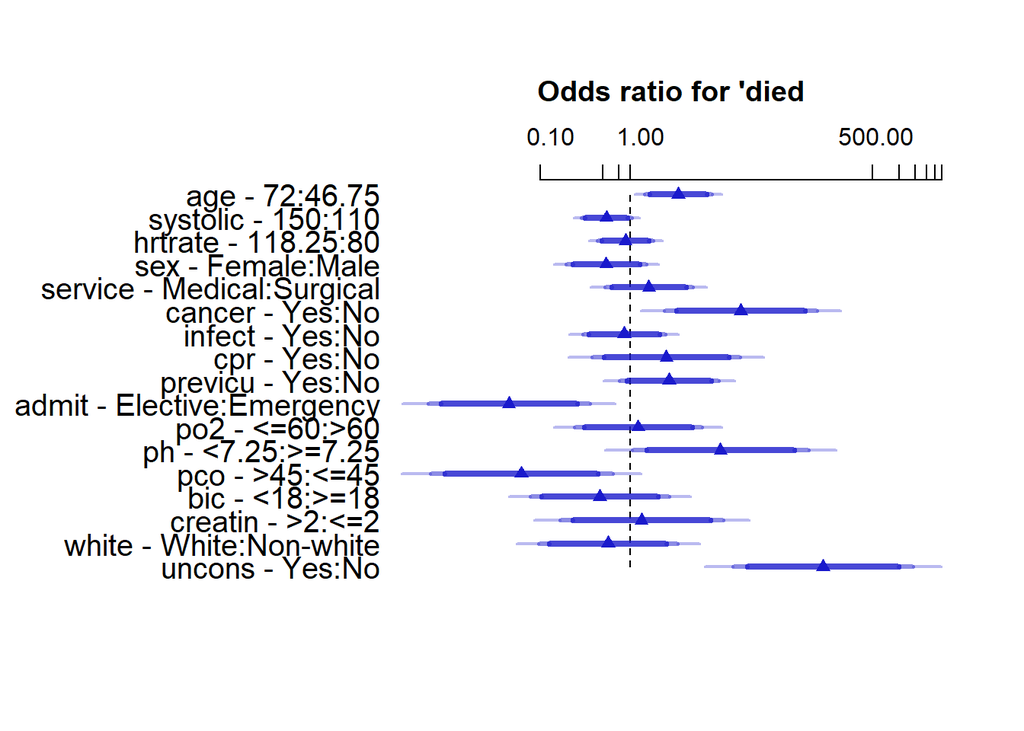

```r
sum.lrm1 <- summary(icu.lrm1)
plot(sum.lrm1, log = TRUE, main = "Odds ratio for 'died",
     cex = 1.25, col = rgb(0.1,0.1,0.8, alpha = c(0.3,0.5,0.8)))
```

`lrm`을 통해 로지스틱 회귀모형을 적합시킨 후, `summary`함수를 통해 적합된 모형에 대해 훨씬 더 상세한 정보를 생성할 수 있다.  
또한, `sumamry`된 `lrm`의 결과를 저장하여 `plot`함수를 통해 시각화를 하게 되면 신뢰구간과 함께 모형 항에 대한 오즈비를 제공한다.  
이 그림에서는 연속형 변수가 맨 위에 먼저 표시된다.  
각 선은 오즈비에 대한 신뢰 구간을 표시하고 세모는 추정된 오즈비를 나타낸다.

**uncons, Cancer, age, ph**의 오즈비가 다른 설명변수들에 비해 크게 추정되는 것을 확인할 수 있다. 즉, 종속변수 **died**에 영향을 많이 끼치는 변수라고 할 수 있다.

```r
library(MASS)
icu.step1 <- stepAIC(icu.full1, trace = FALSE)
icu.step1$anova
```

```
## Stepwise Model Path
## Analysis of Deviance Table
##
## Initial Model:
## died ~ age + sex + service + cancer + infect + cpr + systolic +
##     hrtrate + previcu + admit + po2 + ph + pco + bic + creatin +
##     white + uncons
##
## Final Model:
## died ~ age + cancer + systolic + admit + ph + pco + uncons
##
##
##         Step Df   Deviance Resid. Df Resid. Dev      AIC
## 1                                182   122.4777 158.4777
## 2      - po2  1 0.06244633       183   122.5402 156.5402
## 3  - creatin  1 0.05908007       184   122.5993 154.5993
## 4  - hrtrate  1 0.07237058       185   122.6716 152.6716
## 5   - infect  1 0.12277184       186   122.7944 150.7944
## 6    - white  1 0.33499941       187   123.1294 149.1294
## 7  - service  1 0.67131343       188   123.8007 147.8007
## 8      - bic  1 0.37752109       189   124.1782 146.1782
## 9      - cpr  1 1.14825976       190   125.3265 145.3265
## 10     - sex  1 1.54352276       191   126.8700 144.8700
## 11 - previcu  1 1.56997616       192   128.4400 144.4400
```

```r
icu.step2 <- stepAIC(icu.full, trace = FALSE, k = log(200))
icu.step2$anova
```

```
## Stepwise Model Path
## Analysis of Deviance Table
##
## Initial Model:
## died ~ age + sex + service + cancer + renal + infect + cpr +
##     systolic + hrtrate + previcu + admit + fracture + po2 + ph +
##     pco + bic + creatin + white + uncons
##
## Final Model:
## died ~ age + cancer + admit + uncons
##
##
##          Step Df    Deviance Resid. Df Resid. Dev      AIC
## 1                                  180   120.7783 226.7447
## 2     - renal  1 0.001988058       181   120.7803 221.4484
## 3       - po2  1 0.006796768       182   120.7871 216.1568
## 4   - creatin  1 0.062146344       183   120.8493 210.9207
## 5   - hrtrate  1 0.065886950       184   120.9152 205.6882
## 6    - infect  1 0.203322074       185   121.1185 200.5933
## 7     - white  1 0.367317995       186   121.4858 195.6623
## 8       - bic  1 0.600299257       187   122.0861 190.9642
## 9   - service  1 0.767630316       188   122.8537 186.4335
## 10 - fracture  1 1.324508649       189   124.1782 182.4597
## 11      - cpr  1 1.148259760       190   125.3265 178.3097
## 12      - sex  1 1.543522756       191   126.8700 174.5549
## 13  - previcu  1 1.569976164       192   128.4400 170.8265
## 14       - ph  1 4.441236967       193   132.8812 169.9695
## 15      - pco  1 2.730293352       194   135.6115 167.4014
## 16 - systolic  1 3.523102783       195   139.1346 165.6262
```

`stepwise(단계적 변수선택법)`을 통해 다차원의 변수를 저차원으로 줄일 수 있다. 이때, 표본 크기가 상당히 큰 경우 일반적으로 더 작은 모델을 선택하는 `(k=log())`를 지정하여 사용할 수 있다.  
R에서는 `stepAIC`함수를 사용하여 stepwise를 사용할수 있다.  
- `stepAIC(model)`

- model: stepwise를 적용하고자 하는 모델

```r
lmtest::coeftest(icu.step2)
```

```
##
## z test of coefficients:
##
##                 Estimate Std. Error z value  Pr(>|z|)
## (Intercept)    -6.869779   1.318818 -5.2090 1.898e-07 ***
## age             0.037176   0.012770  2.9112 0.0036003 **
## cancerYes       2.097107   0.838473  2.5011 0.0123808 *
## admitEmergency  3.102182   0.918597  3.3771 0.0007326 ***
## unconsYes       3.705460   0.876473  4.2277 2.361e-05 ***
## ---
## Signif. codes:  0 '***' 0.001 '**' 0.01 '*' 0.05 '.' 0.1 ' ' 1
```

```r
anova(icu.step2, icu.step1, test = "Chisq")
```

```
## Analysis of Deviance Table
##
## Model 1: died ~ age + cancer + admit + uncons
## Model 2: died ~ age + cancer + systolic + admit + ph + pco + uncons
##   Resid. Df Resid. Dev Df Deviance Pr(>Chi)
## 1       195     139.13
## 2       192     128.44  3   10.695   0.0135 *
## ---
## Signif. codes:  0 '***' 0.001 '**' 0.01 '*' 0.05 '.' 0.1 ' ' 1
```

`(k=log())`를 적용한 `icu.step2`와 사용하지 않은 `icu.step1`을 비교한 결과, 유의확률이 유의수준 0.05보다 작으므로 유의한 잔차의 차이가 있는 것을 확인할 수 있다.  
위의 결과를 통해, `Model2(k=log()를 적용하지 않은 모델)`의 잔차가 더 작으므로 `Model1`에 비해 더 적합한 모델임을 확인할 수 있다.

```r
icu.glm3 <- update(icu.step2, . ~ . - age + ns(age,3)+
                     (cancer + admit + uncons) ^ 2)
anova(icu.step2, icu.glm3, test = "Chisq")
```

```
## Analysis of Deviance Table
##
## Model 1: died ~ age + cancer + admit + uncons
## Model 2: died ~ cancer + admit + uncons + ns(age, 3) + cancer:admit +
##     cancer:uncons + admit:uncons
##   Resid. Df Resid. Dev Df Deviance Pr(>Chi)
## 1       195     139.13
## 2       191     135.40  4   3.7329   0.4434
```

`ns(age,3)`을 통해 **age**변수에 대한 3차원의 스플라인과 **cancer,admit,uncons**의 2차식을 추가한 후, 다시 한 번 로지스틱 회귀모형을 적합시켜 보았다.  
`anova`함수를 통해 `stepwise`를 통해 적합시킨 이전 모델과 비교해본 결과 잔차의 차이는 3.73이고 유의확률은 유의수준 0.05보다 크므로 귀무가설을 기각하지 못한다.  
따라서, 변수를 추가하는 것은 유의미한 잔차의 차이를 만들어내지 못하며, 적합하지 않은 모델이라고 할 수 있다.

```r
icu.glm4 <- update(icu.step2, . ~ . + age * (cancer + admit + uncons))
anova(icu.step2, icu.glm4, test = "Chisq")
```

```
## Analysis of Deviance Table
##
## Model 1: died ~ age + cancer + admit + uncons
## Model 2: died ~ age + cancer + admit + uncons + age:cancer + age:admit +
##     age:uncons
##   Resid. Df Resid. Dev Df Deviance Pr(>Chi)
## 1       195     139.13
## 2       192     133.76  3   5.3712   0.1465
```

기존 모형에 **cancer,admit,uncons**변수들의 교호작용을 고려하여 새로운 모델을 만든 후, `stepwise`를 통해 적합시킨 모형들과 비교를 해본 결과, 잔차의 차이는 5.3712이고 유의확률은 유의수준 0.05보다 커 귀무가설을 기각하지 못한다.  
따라서, 교호작용 term을 추가하는 것은 유의미한 잔차의 차이를 만들어내지 못하며, 적합하지 않은 모델이라고 할 수 있다.

*Example 7.12: Death in the ICU - Visualization*

한 가지 흥미로운 시각화 방법은 다양한 설명 변수의 값이 로그 오즈 예측값으로 변환되는 방법과 이러한 예측에 미치는 영향의 상대적 강도를 보여주는 **노모그램(nomogram)**이다.  
`nomogram`은 `rms`패키지에 포함돼있으며, `lrm`을 사용한 모델에만 적용되므로 이 점을 반드시 유의해야한다.  
- `nomogram(model)`

- model: `lrm`함수를 이용하여 적합시킨 모델

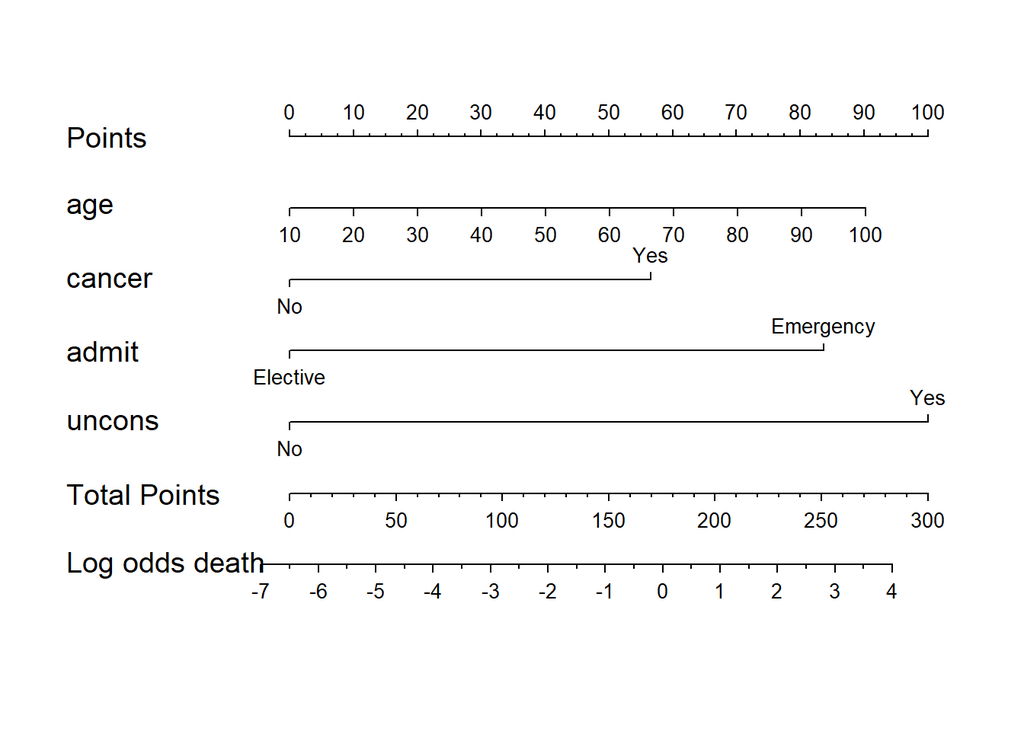

```r
icu.lrm2 <- lrm(died ~ age + cancer + admit + uncons, data = ICU)
plot(nomogram(icu.lrm2), cex.var = 1.2, lplabel = "Log odds death")
```

노모그램에서 각 설명변수는 공통척도 100점에 대한 효과의 크기에 따라 크기가 조정된다.

예를들어, **Age = 60**이고 **Cancer = No**, **admit = Emergency**, **uncons = Yes**인 사람이 있다고 가정하자.  
이러한 경우 총점 척도는 50 + 0 + 84 + 100 = 234점이며, 로그 오즈의 척도는 약 2.2로 계산될 수 있다.

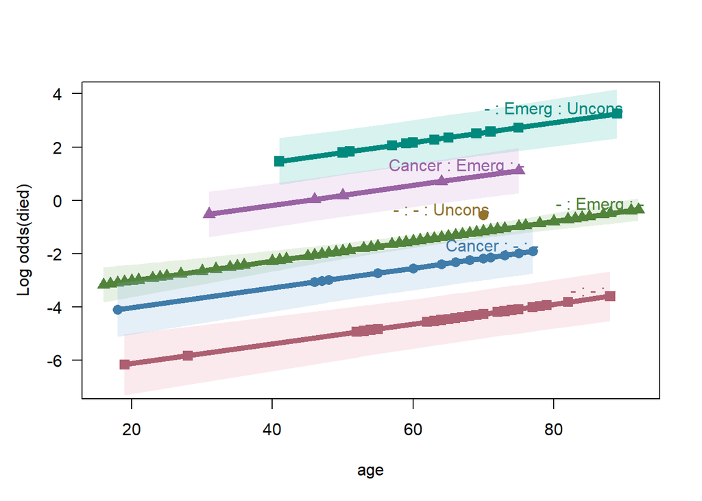

```r
levels(ICU$cancer) <- c("-", "Cancer")
levels(ICU$admit) <- c("-", "Emerg")
levels(ICU$uncons) <- c("-", "Uncons")

icu.glm2 <- glm(died ~ age + cancer + admit + uncons,
                data = ICU, family = binomial)

binreg_plot(icu.glm2, type = "link", conf_level = 0.68,
            legend = FALSE,
            labels = TRUE, labels_just = c("right","bottom"),
            cex = 0, point_size = 0.8, pch = 15:17,
            ylab = "Log odds(died)",
            ylim = c(-7,4))
```

위의 그림의 경우, `labels = TRUE, legend = FALSE`를 이용하여 범례가 박스가 아닌 선에 직접 레이블에 붙여쓰도록 했다.  
사망에 대한 로그오즈는 모든 경우에 **Age**가 증가할수록 서서히 커지는 것을 확인할 수 있다.  
특히, 환자가 **admit = Emergency**인 경우에 로그오즈가 높으며, **admit = Emergency**이면서 **uncons = Yes**일 경우 사망에 대한 로그오즈가 가장 높아진다.

## 7.5 Influence and diagnostic plots

OLS 회귀분석에서 **영향 측도(레버리지, Cook의 D, DFBETA등)** 및 관련 그림을 사용하면 개별 사례가 개별 설명 변수의 적합된 회귀 모델에 과도햔 영향을 미치는지 여부를 결정한다.  
프레기븐은 로지스틱 모델과 가중 최소 제곱 사이의 관계를 이용하여 이러한 방법에 대한 이론적 기초를 제공한다.

### 7.5.1 Residuals and leverage

**잔차(residuals)**는 실제값과 모형으로부터 예측된 값과의 차이를 의미한다.

**레버리지(leverage)**는 개별 사례가 결과에 미치는 잠재적 영향을 측정하며, 개별 사례가 예측 변수 공간의 중심으로부터 얼마나 떨어져 있는지에 정비례한다.

**쿡의거리(Cook’s Distance)**는 i번째 관측치를 포함했을때와 포함하지 않았을 때의 적합치 사이의 거리를 계산한다. 일반적으로 기준값이 1보다 클 경우 이상치로 간주한다.

**DFBETA**는 i번째 관측치가 DFBETA의 기준값인 2 또는 $2/sqrt(n)$보다 크면 이상치로 간주한다.

### 7.5.2 Influence diagnostics

*Example 7.13: Donner Party*

```r
inf1 <- influence.measures(donner.mod3)
names(inf1)
```

```
## [1] "infmat" "is.inf" "call"
```

적합시킨 모델에 대한 모든 진단 측정의 세부사항은 `influence.measures`함수를 사용하여 얻을 수 있다.  
- `influence.measures(model)`

- model: 진단하고자 하는 적합된 모델

```r
summary(inf1)
```

```
## Potentially influential observations of
##   glm(formula = survived ~ poly(age, 2) + sex, family = binomial,      data = Donner) :
##
##                      dfb.1_ dfb.p(,2)1 dfb.p(,2)2 dfb.sxMl dffit   cov.r
## Breen, Patrick        0.08   0.65       0.56       0.23     0.69_*  0.93
## Donner, Elizabeth    -0.26  -0.34      -0.22       0.12    -0.40    1.15_*
## Graves, Elizabeth C. -0.24  -0.37      -0.26       0.10    -0.42    1.20_*
##                      cook.d hat
## Breen, Patrick        0.32   0.09
## Donner, Elizabeth     0.03   0.14_*
## Graves, Elizabeth C.  0.03   0.16_*
```

`influence.measures`를 적용한 결과를 `summary`함수를 통해 쉽게 살펴볼 수 있다.  
영향치로 판단되는 경우 `*`표시가 나타나는 것을 볼 수 있다.  
**Breen, Patrick**의 경우, **dffit** 측도가 영향치라고 판단을 하며, **Donner, Elizabetch**, **Graves, Elizabetch C.**의 경우, **cov.r, hat**측도가 영향치라고 판단했다.

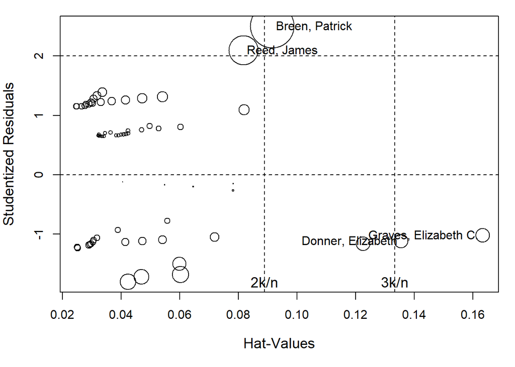

```r
op <- par(mar = c(5,4,1,1) + .1, cex.lab = 1.2)
res <- influencePlot(donner.mod3, id.col = "blue", scale = 8, id.n = 2)
k <- length(coef(donner.mod3))
n <- nrow(Donner)
text(x = c(2,3) * k / n, y = -1.8, c("2k/n", "3k/n"), cex = 1.2)
```

위의 그래프의 경우, `donner.mod3`에 대한 영향 측정 진단 및 진단 그림이며, **쿡의 D**값을 보여주기 위해 플롯 기호의 크기를 추가로 사용하는 `car`패키지의 `influencePlot`의 결과이다.  
`influenceplot`은 원의 영역이 쿡의 거리에 비례하는 관측치를 나타내는 **표준화 잔차**대 **hat value**의 원 그림을 그려준다.  
- `influenceplot(model)`

- model; 영향 측정 진단을 하고자 하는 적합된 모델

점에 대한 영향 통계량이 포함된 데이터 프레임을 통해 이러한 점이 영향력 있는 것으로 간주되는 것을 알 수 있다.  
수평 및 수직 기준선은 주목할 만한 잔차 및 레버리지에 대한 일반적인 컷오프 값을 나타낸다.  
`id.n`인수는 각 표준화된 잔차, hat value, Cook’s에 대해 `id.n`만큼의 가장 극단적인 관측치를 선택한다.

앞선 결과에서도 볼 수 있듯이, **Donner, Elizabetch**, **Graves, Elizabetch C.**의 경우, **Hat-Values**에서 영향치라고 판단하는 것을 다시 한 번 볼 수 있다.

```r
idx <- which(rownames(Donner) %in% rownames(res))
cbind(Donner[idx,2:4],res)
```

```
##                      age    sex survived   StudRes        Hat      CookD
## Breen, Patrick        51   Male      yes  2.501048 0.09148358 0.32353863
## Donner, Elizabeth     45 Female       no -1.113711 0.13540740 0.03409178
## Graves, Elizabeth C.  47 Female       no -1.018516 0.16322227 0.03417604
## Reed, James           46   Male      yes  2.097962 0.08161950 0.14363764
```

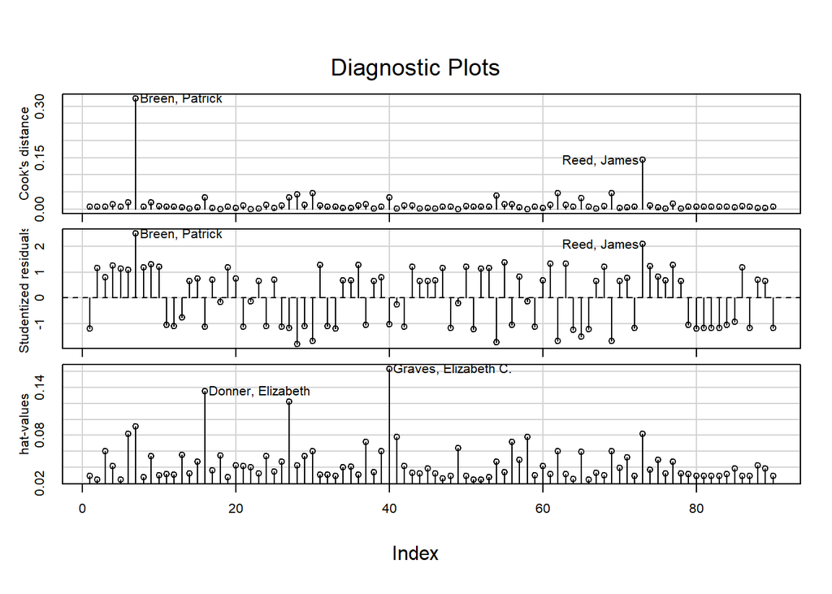

```r
influenceIndexPlot(donner.mod3, vars = c("Cook", "Studentized", "hat"), id.n=4)
```

`influenceIndexPlot`의 경우 데이터의 관측번호에 대한 다양한 영향 진단을 통해 극단적인 관측치들을 파악할 수 있으며, `car`패키지에 포함돼있다.  
- `influenceIndexPlot(model,vars)`